# Analyses of PRJNA1152621

## Correlation with m6A

```r
m6A <- read_excel("~/Projects/StressGranules/SG_Transcriptome/m6A/41467_2022_31358_MOESM26_ESM.xlsx")[,c(4,16,17)]
```

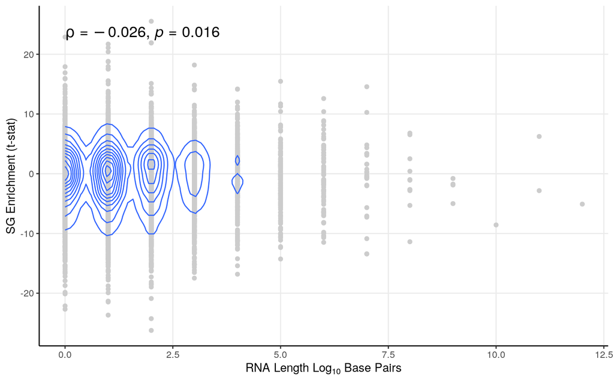

```r
colnames(m6A)[1] <- "Gene"

DEGenes <- merge(DEGenes, m6A, by="Gene")

ggplot(DEGenes, aes(y=t, x=(m6a_sites))) + geom_point(color="#CCCCCC", alpha=1) +   theme_bw()+ geom_density_2d()+
 ylab("SG Enrichment (t-stat)") + xlab(expression(RNA ~ Length ~ Log[10] ~ Base ~ Pairs)) +
  theme(axis.line = element_line(colour = "black"),
        panel.grid.minor = element_blank(),
        panel.border = element_blank(),
        panel.background = element_blank()) +
  theme(plot.title = element_text(hjust = 0.5)) + stat_cor(method = "spearman", cor.coef.name = "rho", size=5)
```

And as expected, since the lenght bias dissapeared, we also lost the correlation with the number of m6A sites.

## Expression Graphs (Extra QC)

As an added control, lets plot these genes in regard to their expression. This helps to see if the expression differences are robust, and not just driven by one sample.

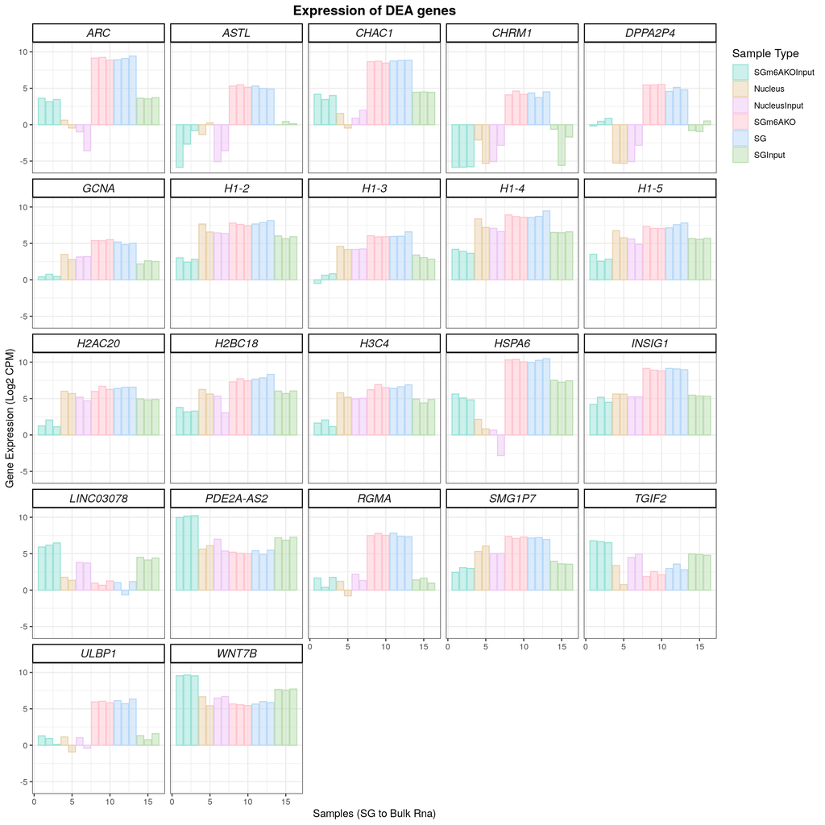

```r
finagenes <- rbind(upmarkers, downmarkers)


dfforexpression <- dfforpca
samplecodes <- data.frame(samples=row.names(dfforexpression), purity=c(1:16))
sampletype <- data.frame(samples=row.names(dfforexpression), sampletype=Sample_names)
dfforexpression <- t(dfforexpression)
genesforexp <- dfforexpression[row.names(dfforexpression)%in%row.names(finagenes),]
genesforexp <- reshape2::melt(genesforexp)
colnames(genesforexp) <- c("Gene", "samples", "expression")
genesforexp <- merge(genesforexp, samplecodes, by="samples")
genesforexp <- merge(genesforexp, sampletype, by="samples")
genesforexp <- genesforexp[,-1]
genesforexp[,2] <- as.numeric(genesforexp[,2])
genesforexp[,1] <- as.character(genesforexp[,1])
genesforexp <- genesforexp[order(genesforexp$Gene),]


winnyplot <- ggplot(genesforexp, aes(x=purity, y=expression, fill=sampletype, colour=sampletype)) + geom_bar(position="dodge", stat="identity", alpha=0.5) + facet_wrap(.~ Gene, ncol=5)
winnyplot <- winnyplot + scale_fill_manual(name = "Sample Type", values = custom_palette, breaks = unique(Sample_names)) + scale_colour_manual(name = "Sample Type", values = custom_palette, breaks = unique(Sample_names))
winnyplot <- winnyplot + theme_bw() + xlab("Samples (SG to Bulk Rna)") + ylab("Gene Expression (Log2 CPM)") + theme(
      strip.text.x = element_text(
        size = 12, face="italic"
        )) +
 theme(
   strip.background = element_rect(
     color="black", fill="#FFFFFF", size=1, linetype="solid"
     )
   ) + theme(
    #legend.position = c(.95, .40),
    legend.justification = c("right", "top"),
    legend.box.just = "right",
    ) + theme(legend.title = element_text(size = 12)) + ggtitle("Expression of DEA genes") + theme(plot.title = element_text(hjust = 0.5, size=14, face="bold"))
winnyplot
```

## GSEA Enrichment

Now that we have our genes of interest, it would also be interesting to see what are the **altered gene sets** between upregulated and downregulated transcripts from the above comparison. Therefore, lets perform a *Gene Set Enrichment Analysis*

```r
#for all genes
DEGenes <- DEGenes[order(DEGenes[,4]),]
gseatool <- DEGenes[,4]
gseatool <- as.data.frame(gseatool)
colnames(gseatool)[1] <- "t"
gseatool[,2] <- DEGenes$Gene
colnames(gseatool)[2] <- "Symbol"
gseatool <- gseatool[,c(2,1)]

vectorranks <- gseatool$t
names(vectorranks) <- gseatool$Symbol


#to load our pathways
hallmarks.gs <- msigdbr(species = "Homo sapiens", collection =  "H")

hallmarks.gsets <- hallmarks.gs %>% split(x = .$gene_symbol, f = .$gs_name)

for (set in names(hallmarks.gsets)){
  hallmarks.gsets[[set]] <- toupper(hallmarks.gsets[[set]])
}

hallmarks.res <- fgsea(pathways = hallmarks.gsets,
                       stats = vectorranks)
```

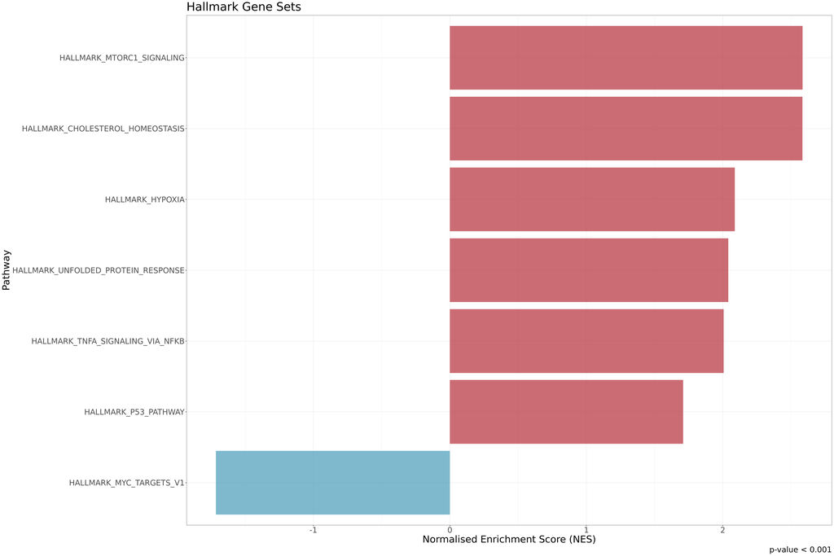

```r
hallmarks.res.tidy <- hallmarks.res %>%
  as_tibble() %>%
  arrange(desc(NES))

hallmarks.res.tidy %>%
  dplyr::select(-leadingEdge, -ES) %>%
  arrange(padj)

hallmark.sg.t <- hallmarks.res.tidy[,c(1,3,6)]
hallmark.sg.t <- as.data.frame(hallmark.sg.t)

#this small part is generic
thresh <- 0.001

#this one is no longer generic
data_to_plot <- hallmarks.res.tidy %>% filter(padj < thresh)

statvec <- c()
for (i in 1:nrow(data_to_plot)){
  if (data_to_plot[i,6] > 0){
    status <- "Upregulated"
  }
 else {
   status <- "Downregulated"
 }
statvec <- c(statvec, status)
}

data_to_plot$Status <- statvec

##-----HALMARK-----
gsea_plot_hall <- ggplot(data_to_plot, aes(reorder(pathway, NES), NES)) +
  geom_col(aes(fill= Status), alpha=0.75) + scale_fill_manual(values = c("#53A2BE","#BA3B46"), name = "Regulation Status", labels = c("Downregulated", "Upregulated"), breaks = c("Downregulated", "Upregulated")) +
  coord_flip() +
  labs(x="Pathway", y="Normalised Enrichment Score (NES)",
       title= "Hallmark Gene Sets",
       caption = paste0("p-value < ", thresh)) + theme(plot.title = element_text(hjust = 1)) +
  theme_bw() + theme(text=element_text(family = "Quicksand")) + theme(legend.position = "none")


gsea_plot_hall+
  theme(text=element_text(size=25,  family="Arial MS"))
```

# SG vs SG

## Linear Models

Now we must perform linear model fitting. Now, I will directly compare the SG with m6A with the SG without m6A.

```r
fitted <- lmFit(y, mm)
head(coef(fitted))
```

```
##         Sample_namesNucleus Sample_namesNucleusInput Sample_namesSG
## 7SK               11.346120                10.638360      10.038966
## A2M                8.405718                 7.959729       7.852911
## A2M-AS1            3.352390                 3.772179       2.941500
## A4GALT             5.147467                 4.681280       4.536228
## AAAS               6.704408                 6.373518       5.659063
## AACS               6.115492                 5.492285       5.921533
##         Sample_namesSGInput Sample_namesSGm6AKO Sample_namesSGm6AKOInput
## 7SK               10.524509            9.241555                 5.914142
## A2M                4.484204            7.583546                 3.835835
## A2M-AS1            1.498057            2.167834                 1.259809
## A4GALT             5.059354            4.556102                 4.344565
## AAAS               6.022231            5.331567                 5.560717
## AACS               4.937250            6.154849                 4.320387
```

```r
#next we measure contrasts between groups (log-fold change is obtained from these fitted linear models)
contr<- makeContrasts(Sample_namesSG      - Sample_namesSGm6AKO      , levels = mm)


#next we estimate the contrast for each gene
tmp <- contrasts.fit(fitted, contr)


#use empirical bayes smoothing of standard erros (shrinks extreme standard erros)
tmp <- eBayes(tmp)
top.table <- topTable(tmp, sort.by = "logFC", n = Inf)
DEGenes <- top.table
ndegs=20
```

## Volcano Plot

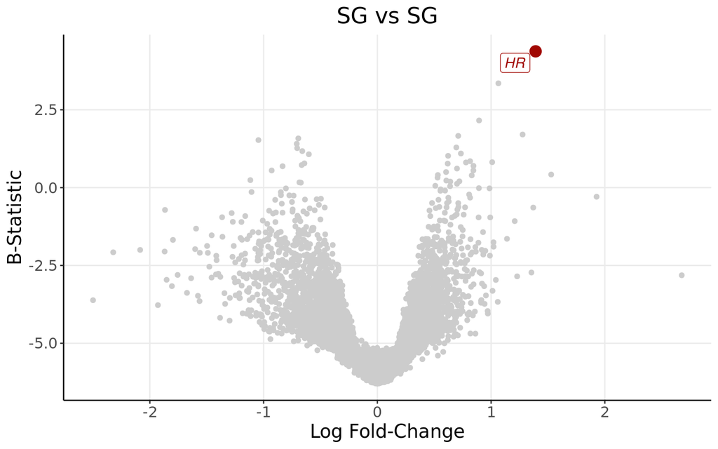

```r
upmarkers <- as.data.frame(DEGenes[DEGenes$logFC>1 & DEGenes$adj.P.Val<0.05,] )
downmarkers <- as.data.frame(DEGenes[DEGenes$logFC< -1 & DEGenes$adj.P.Val<0.05,] )

ggplot(data=DEGenes,
                 aes(x=logFC,
                     y=  B)) +
  geom_point(color="#CCCCCC")+
  theme_bw() + ylab("B-Statistic")+xlab("Log Fold-Change")+
  theme(axis.line = element_line(colour = "black"),
        panel.grid.minor = element_blank(),
        panel.border = element_blank(),
        panel.background = element_blank()) +
  ggtitle("SG vs SG")+
  theme(plot.title = element_text(hjust = 0.5), plot.subtitle = element_text(hjust = 0.5)) +
  geom_point(data=upmarkers, aes(x=logFC, y=  B), color="#A10702",size=4)+
  geom_point(data=downmarkers, aes(x=logFC, y=  B), color="#03256C",size=4)+
  geom_label_repel(upmarkers[1:ndegs,] , mapping=aes(label=row.names(upmarkers)[1:ndegs]),size=4,point.padding=-0.5, color="#A10702",max.overlaps = 20, fontface="italic")+
  geom_label_repel(downmarkers[1:ndegs,] , mapping=aes(label=row.names(downmarkers)[1:ndegs]),size=4,point.padding=-0.5, color="#03256C",max.overlaps = 20, fontface="italic")+
  theme(text=element_text(size=15,  family="Arial MS"))
```

The differences between them are very small. Can we really say m6A is important for SG enrichment when apparently they are “the same”?

## Volcano Plot with Gene Length

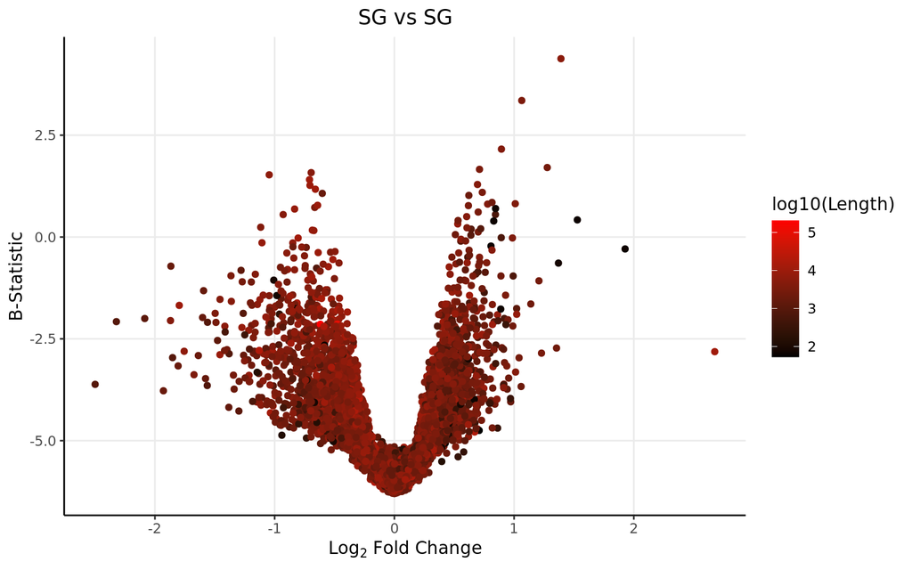

```r
DEGenes$Gene <- row.names(DEGenes)
colnames(genelength) <- c("Length","Gene")
DEGenes <- merge(DEGenes, genelength, by="Gene")

ggplot(data=DEGenes,
                 aes(x=logFC,
                     y=  B)) +
  geom_point(aes(color=log10(Length)))+
  theme_bw() +
  theme(axis.line = element_line(colour = "black"),
        panel.grid.minor = element_blank(),
        panel.border = element_blank(),
        panel.background = element_blank()) +
  ggtitle("SG vs SG")+ xlab(expression(Log[2] ~ Fold ~ Change)) + ylab("B-Statistic") +
  theme(plot.title = element_text(hjust = 0.5))  +
  scale_colour_gradient(low = "black", high = "red")+ theme(text=element_text(family = "Quicksand"))
```

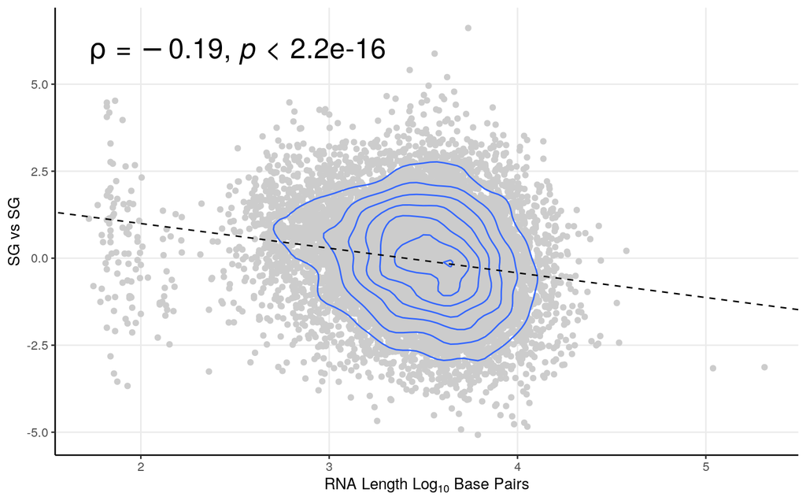

```r
smooth.SG <- lm(t~log10(Length), DEGenes)
liner.SG <- rstandard(smooth.SG)
DEGenes <-cbind(DEGenes, liner.SG)
colnames(DEGenes)[9] <- "Residuals"
row.names(DEGenes) <- DEGenes$Gene
linemarkers <- as.data.frame(DEGenes[abs(DEGenes$Residuals)>4,])

# Calculate the Spearman correlation coefficient
spearman_corr <- cor(DEGenes$t, log10(DEGenes$Length), method = "spearman")



ggplot(DEGenes, aes(y=t, x=log10(Length))) + geom_point(color="#CCCCCC", alpha=1) +   theme_bw()+ geom_density_2d()+
 ylab("SG vs SG") + xlab(expression(RNA ~ Length ~ Log[10] ~ Base ~ Pairs)) +
  theme(axis.line = element_line(colour = "black"),
        panel.grid.minor = element_blank(),
        panel.border = element_blank(),
        panel.background = element_blank()) +
  theme(plot.title = element_text(hjust = 0.5))  +
  geom_abline(slope=smooth.SG$coefficients[2], intercept = smooth.SG$coefficients[1], linetype = "dashed")+ stat_cor(method = "spearman", cor.coef.name = "rho",size=7)
```

## Correlation with m6A

```r
m6A <- read_excel("~/Projects/StressGranules/SG_Transcriptome/m6A/41467_2022_31358_MOESM26_ESM.xlsx")[,c(4,16,17)]
```

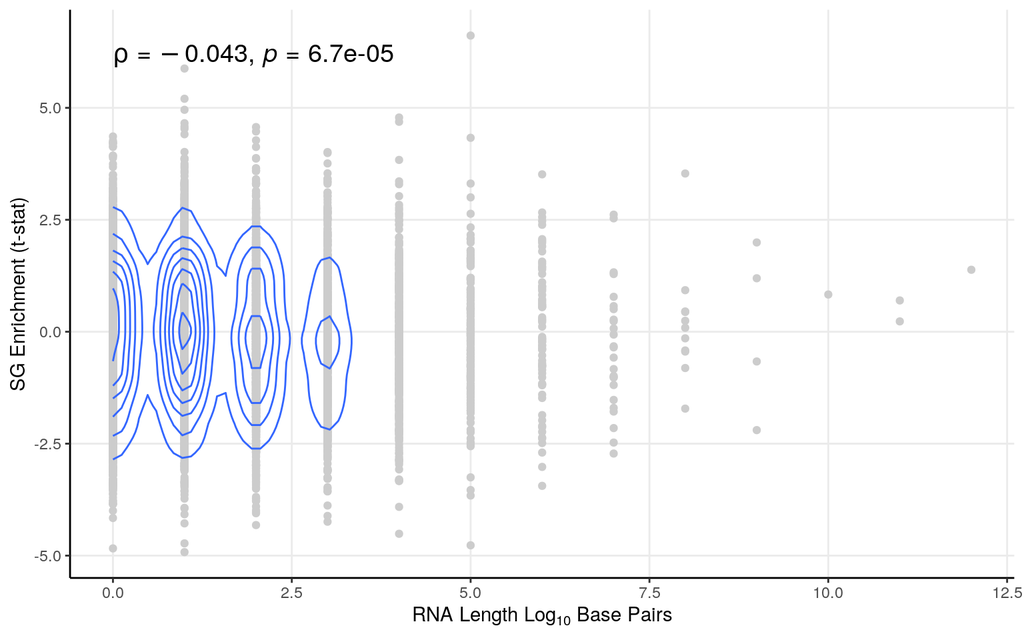

```r
colnames(m6A)[1] <- "Gene"

DEGenes <- merge(DEGenes, m6A, by="Gene")

ggplot(DEGenes, aes(y=t, x=(m6a_sites))) + geom_point(color="#CCCCCC", alpha=1) +   theme_bw()+ geom_density_2d()+
 ylab("SG Enrichment (t-stat)") + xlab(expression(RNA ~ Length ~ Log[10] ~ Base ~ Pairs)) +
  theme(axis.line = element_line(colour = "black"),
        panel.grid.minor = element_blank(),
        panel.border = element_blank(),
        panel.background = element_blank()) +
  theme(plot.title = element_text(hjust = 0.5)) + stat_cor(method = "spearman", cor.coef.name = "rho", size=5)
```

There were barely any differences, and it doesn’t seem like they are linked to number of m6A modifications at all.

## GSEA Enrichment

Now that we have our genes of interest, it would also be interesting to see what are the **altered gene sets** between upregulated and downregulated transcripts from the above comparison. Therefore, lets perform a *Gene Set Enrichment Analysis*

```r
#for all genes
DEGenes <- DEGenes[order(DEGenes[,4]),]
gseatool <- DEGenes[,4]
gseatool <- as.data.frame(gseatool)
colnames(gseatool)[1] <- "t"
gseatool[,2] <- DEGenes$Gene
colnames(gseatool)[2] <- "Symbol"
gseatool <- gseatool[,c(2,1)]

vectorranks <- gseatool$t
names(vectorranks) <- gseatool$Symbol


#to load our pathways
hallmarks.gs <- msigdbr(species = "Homo sapiens", collection =  "H")

hallmarks.gsets <- hallmarks.gs %>% split(x = .$gene_symbol, f = .$gs_name)

for (set in names(hallmarks.gsets)){
  hallmarks.gsets[[set]] <- toupper(hallmarks.gsets[[set]])
}

hallmarks.res <- fgsea(pathways = hallmarks.gsets,
                       stats = vectorranks)
```

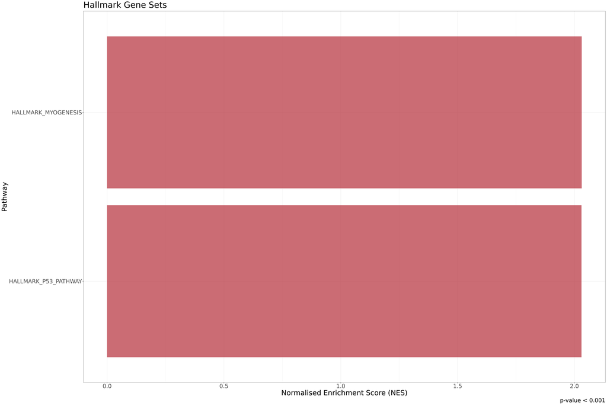

```r
hallmarks.res.tidy <- hallmarks.res %>%
  as_tibble() %>%
  arrange(desc(NES))

hallmarks.res.tidy %>%
  dplyr::select(-leadingEdge, -ES) %>%
  arrange(padj)

hallmark.sg.t <- hallmarks.res.tidy[,c(1,3,6)]
hallmark.sg.t <- as.data.frame(hallmark.sg.t)

#this small part is generic
thresh <- 0.001

#this one is no longer generic
data_to_plot <- hallmarks.res.tidy %>% filter(padj < thresh)

statvec <- c()
for (i in 1:nrow(data_to_plot)){
  if (data_to_plot[i,6] > 0){
    status <- "Upregulated"
  }
 else {
   status <- "Downregulated"
 }
statvec <- c(statvec, status)
}

data_to_plot$Status <- statvec

##-----HALMARK-----
gsea_plot_hall <- ggplot(data_to_plot, aes(reorder(pathway, NES), NES)) +
  geom_col(aes(fill= Status), alpha=0.75) + scale_fill_manual(values = c("#53A2BE","#BA3B46"), name = "Regulation Status", labels = c("Downregulated", "Upregulated"), breaks = c("Downregulated", "Upregulated")) +
  coord_flip() +
  labs(x="Pathway", y="Normalised Enrichment Score (NES)",
       title= "Hallmark Gene Sets",
       caption = paste0("p-value < ", thresh)) + theme(plot.title = element_text(hjust = 1)) +
  theme_bw() + theme(text=element_text(family = "Quicksand")) + theme(legend.position = "none")


gsea_plot_hall+
  theme(text=element_text(size=25,  family="Arial MS"))
```

# WC vs WC

## Linear Models

Now we must perform linear model fitting.

```r
fitted <- lmFit(y, mm)
head(coef(fitted))
```

```
##         Sample_namesNucleus Sample_namesNucleusInput Sample_namesSG
## 7SK               11.346120                10.638360      10.038966
## A2M                8.405718                 7.959729       7.852911
## A2M-AS1            3.352390                 3.772179       2.941500
## A4GALT             5.147467                 4.681280       4.536228
## AAAS               6.704408                 6.373518       5.659063
## AACS               6.115492                 5.492285       5.921533
##         Sample_namesSGInput Sample_namesSGm6AKO Sample_namesSGm6AKOInput
## 7SK               10.524509            9.241555                 5.914142
## A2M                4.484204            7.583546                 3.835835
## A2M-AS1            1.498057            2.167834                 1.259809
## A4GALT             5.059354            4.556102                 4.344565
## AAAS               6.022231            5.331567                 5.560717
## AACS               4.937250            6.154849                 4.320387
```

```r
#next we measure contrasts between groups (log-fold change is obtained from these fitted linear models)
contr<- makeContrasts(Sample_namesSGInput       - Sample_namesSGm6AKOInput, levels = mm)


#next we estimate the contrast for each gene
tmp <- contrasts.fit(fitted, contr)


#use empirical bayes smoothing of standard erros (shrinks extreme standard erros)
tmp <- eBayes(tmp)
top.table <- topTable(tmp, sort.by = "logFC", n = Inf)
DEGenes <- top.table
ndegs=20
```

## Volcano Plot

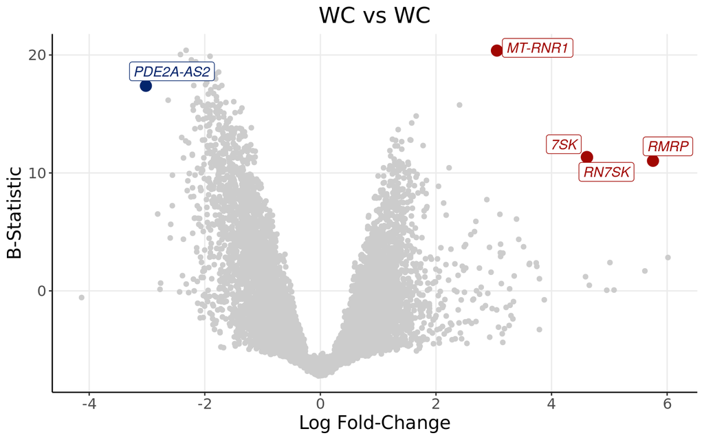

```r
upmarkers <- as.data.frame(DEGenes[DEGenes$logFC>3 & DEGenes$B>10,] )
downmarkers <- as.data.frame(DEGenes[DEGenes$logFC< -3 & DEGenes$B>10,] )

ggplot(data=DEGenes,
                 aes(x=logFC,
                     y=  B)) +
  geom_point(color="#CCCCCC")+
  theme_bw() + ylab("B-Statistic")+xlab("Log Fold-Change")+
  theme(axis.line = element_line(colour = "black"),
        panel.grid.minor = element_blank(),
        panel.border = element_blank(),
        panel.background = element_blank()) +
  ggtitle("WC vs WC")+
  theme(plot.title = element_text(hjust = 0.5), plot.subtitle = element_text(hjust = 0.5)) +
  geom_point(data=upmarkers, aes(x=logFC, y=  B), color="#A10702",size=4)+
  geom_point(data=downmarkers, aes(x=logFC, y=  B), color="#03256C",size=4)+
  geom_label_repel(upmarkers[1:ndegs,] , mapping=aes(label=row.names(upmarkers)[1:ndegs]),size=4,point.padding=-0.5, color="#A10702",max.overlaps = 20, fontface="italic")+
  geom_label_repel(downmarkers[1:ndegs,] , mapping=aes(label=row.names(downmarkers)[1:ndegs]),size=4,point.padding=-0.5, color="#03256C",max.overlaps = 20, fontface="italic")+
  theme(text=element_text(size=15,  family="Arial MS"))
```

## Volcano Plot with Gene Length

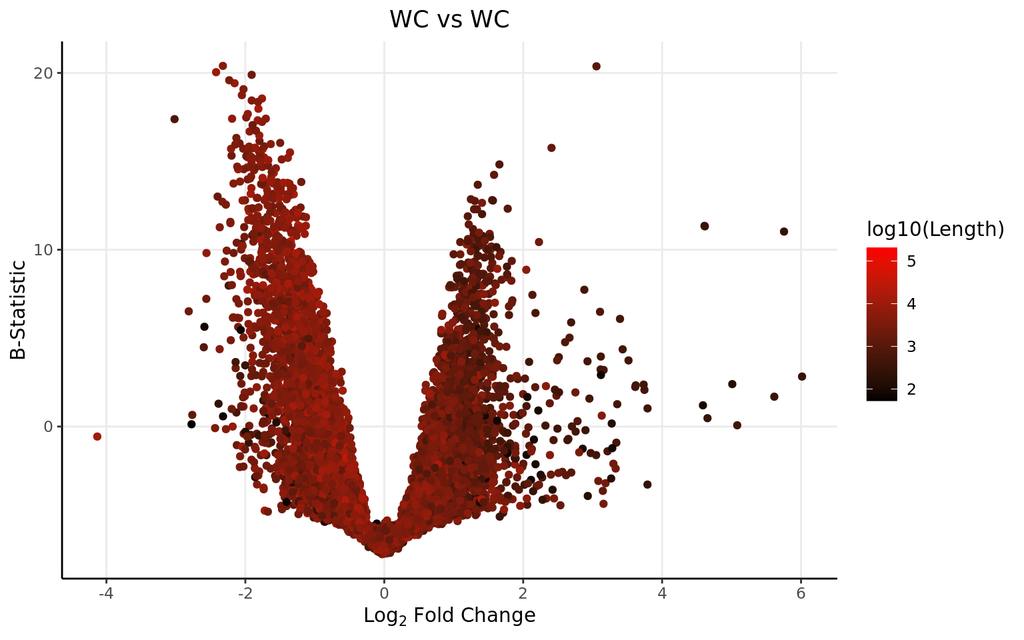

```r
DEGenes$Gene <- row.names(DEGenes)
colnames(genelength) <- c("Length","Gene")
DEGenes <- merge(DEGenes, genelength, by="Gene")

ggplot(data=DEGenes,
                 aes(x=logFC,
                     y=  B)) +
  geom_point(aes(color=log10(Length)))+
  theme_bw() +
  theme(axis.line = element_line(colour = "black"),
        panel.grid.minor = element_blank(),
        panel.border = element_blank(),
        panel.background = element_blank()) +
  ggtitle("WC vs WC")+ xlab(expression(Log[2] ~ Fold ~ Change)) + ylab("B-Statistic") +
  theme(plot.title = element_text(hjust = 0.5))  +
  scale_colour_gradient(low = "black", high = "red")+ theme(text=element_text(family = "Quicksand"))
```

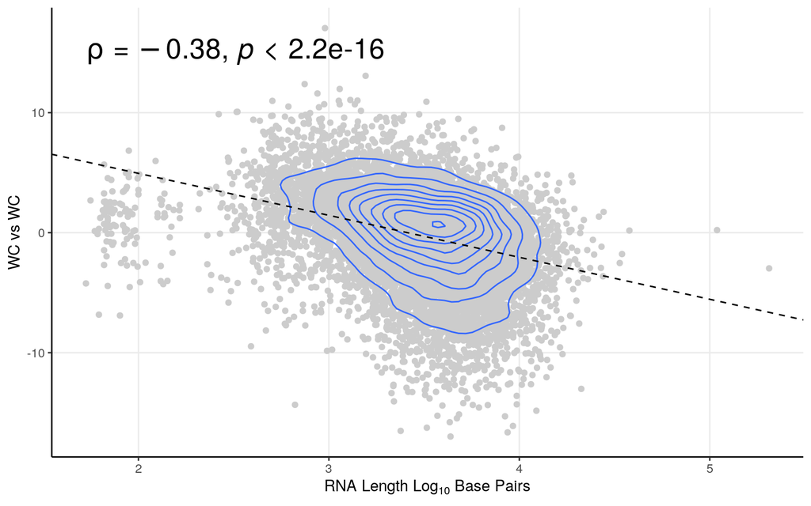

```r
smooth.SG <- lm(t~log10(Length), DEGenes)
liner.SG <- rstandard(smooth.SG)
DEGenes <-cbind(DEGenes, liner.SG)
colnames(DEGenes)[9] <- "Residuals"
row.names(DEGenes) <- DEGenes$Gene
linemarkers <- as.data.frame(DEGenes[abs(DEGenes$Residuals)>4,])

# Calculate the Spearman correlation coefficient
spearman_corr <- cor(DEGenes$t, log10(DEGenes$Length), method = "spearman")



ggplot(DEGenes, aes(y=t, x=log10(Length))) + geom_point(color="#CCCCCC", alpha=1) +   theme_bw()+ geom_density_2d()+
 ylab("WC vs WC") + xlab(expression(RNA ~ Length ~ Log[10] ~ Base ~ Pairs)) +
  theme(axis.line = element_line(colour = "black"),
        panel.grid.minor = element_blank(),
        panel.border = element_blank(),
        panel.background = element_blank()) +
  theme(plot.title = element_text(hjust = 0.5))  +
  geom_abline(slope=smooth.SG$coefficients[2], intercept = smooth.SG$coefficients[1], linetype = "dashed")+ stat_cor(method = "spearman", cor.coef.name = "rho",size=7)
```

Cells without m6A are “much longer” than their WT counterparts.

## GSEA Enrichment

Now that we have our genes of interest, it would also be interesting to see what are the **altered gene sets** between upregulated and downregulated transcripts from the above comparison. Therefore, lets perform a *Gene Set Enrichment Analysis*

```r
#for all genes
DEGenes <- DEGenes[order(DEGenes[,4]),]
gseatool <- DEGenes[,4]
gseatool <- as.data.frame(gseatool)
colnames(gseatool)[1] <- "t"
gseatool[,2] <- DEGenes$Gene
colnames(gseatool)[2] <- "Symbol"
gseatool <- gseatool[,c(2,1)]

vectorranks <- gseatool$t
names(vectorranks) <- gseatool$Symbol


#to load our pathways
hallmarks.gs <- msigdbr(species = "Homo sapiens", collection =  "H")

hallmarks.gsets <- hallmarks.gs %>% split(x = .$gene_symbol, f = .$gs_name)

for (set in names(hallmarks.gsets)){
  hallmarks.gsets[[set]] <- toupper(hallmarks.gsets[[set]])
}

hallmarks.res <- fgsea(pathways = hallmarks.gsets,
                       stats = vectorranks)
```

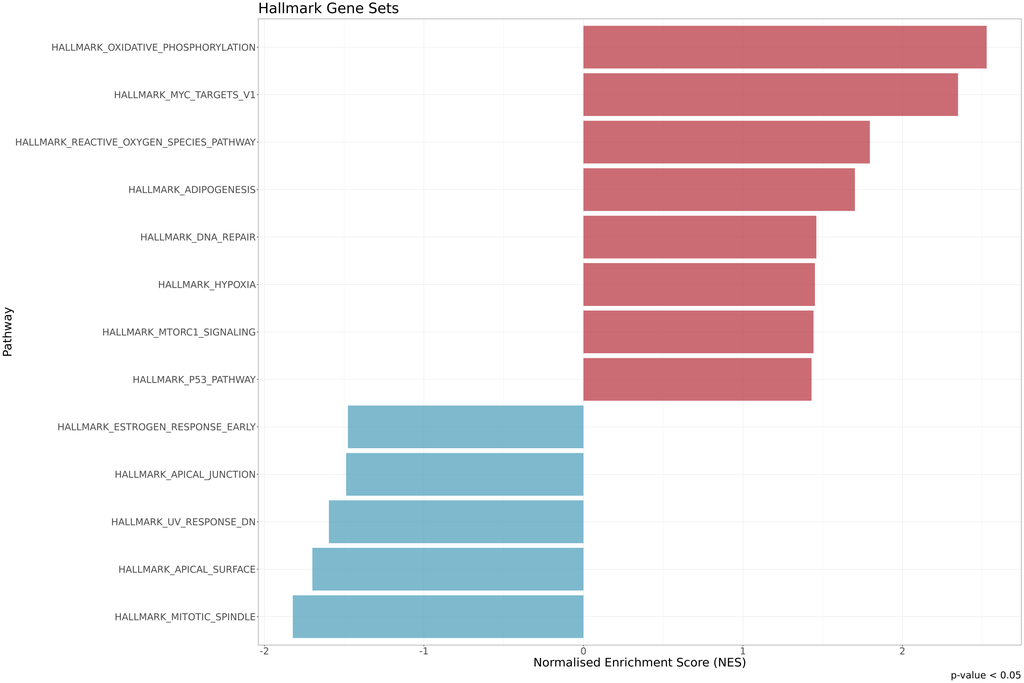

```r
hallmarks.res.tidy <- hallmarks.res %>%
  as_tibble() %>%
  arrange(desc(NES))

hallmarks.res.tidy %>%
  dplyr::select(-leadingEdge, -ES) %>%
  arrange(padj)

hallmark.sg.t <- hallmarks.res.tidy[,c(1,3,6)]
hallmark.sg.t <- as.data.frame(hallmark.sg.t)

#this small part is generic
thresh <- 0.05

#this one is no longer generic
data_to_plot <- hallmarks.res.tidy %>% filter(padj < thresh)

statvec <- c()
for (i in 1:nrow(data_to_plot)){
  if (data_to_plot[i,6] > 0){
    status <- "Upregulated"
  }
 else {
   status <- "Downregulated"
 }
statvec <- c(statvec, status)
}

data_to_plot$Status <- statvec

##-----HALMARK-----
gsea_plot_hall <- ggplot(data_to_plot, aes(reorder(pathway, NES), NES)) +
  geom_col(aes(fill= Status), alpha=0.75) + scale_fill_manual(values = c("#53A2BE","#BA3B46"), name = "Regulation Status", labels = c("Downregulated", "Upregulated"), breaks = c("Downregulated", "Upregulated")) +
  coord_flip() +
  labs(x="Pathway", y="Normalised Enrichment Score (NES)",
       title= "Hallmark Gene Sets",
       caption = paste0("p-value < ", thresh)) + theme(plot.title = element_text(hjust = 1)) +
  theme_bw() + theme(text=element_text(family = "Quicksand")) + theme(legend.position = "none")


gsea_plot_hall+
  theme(text=element_text(size=25,  family="Arial MS"))
```

# Stress vs Unstress (proper)

## Linear Models

Now we must perform linear model fitting.

```r
sampnamer <- c(rep("SGkoin",3), rep("Nuc",2), rep("Nucin",2), rep("SGko",3), rep("SG",3), rep("SGin",3))

Stress <- c(rep("Yes",3), rep("No",2), rep("No",2), rep("Yes",3), rep("Yes",3), rep("Yes",3))

Sample <- c(rep("WC",3), rep("Nuc",2), rep("WC",2), rep("SG",3), rep("SG",3), rep("WC",3))

m6A <- c(rep("KO",3), rep("WT",2), rep("WT",2), rep("KO",3), rep("WT",3), rep("WT",3))

mm <- model.matrix(~0+Stress+Sample+m6A)

fitted <- lmFit(y, mm)
head(coef(fitted))
```

```
##         StressNo StressYes   SampleSG   SampleWC       m6AWT
## 7SK     9.081096 8.2292275  0.2631300 -0.7077593 2.265023268
## A2M     8.066650 4.4539964  3.0937534 -0.4459891 0.339068096
## A2M-AS1 2.707928 0.6351743  1.6146306  0.4197889 0.644462111
## A4GALT  4.867469 5.0541717 -0.6537385 -0.4661879 0.279998714
## AAAS    6.318540 5.9314892 -0.6318346 -0.3308896 0.385868180
## AACS    6.112054 5.2804295  0.7564077 -0.6232066 0.003437841
```

```r
#next we measure contrasts between groups (log-fold change is obtained from these fitted linear models)
contr<- makeContrasts(StressYes         - StressNo      , levels = mm)


#next we estimate the contrast for each gene
tmp <- contrasts.fit(fitted, contr)


#use empirical bayes smoothing of standard erros (shrinks extreme standard erros)
tmp <- eBayes(tmp)
top.table <- topTable(tmp, sort.by = "logFC", n = Inf)
DEGenes <- top.table
ndegs=20
```

## Volcano Plot

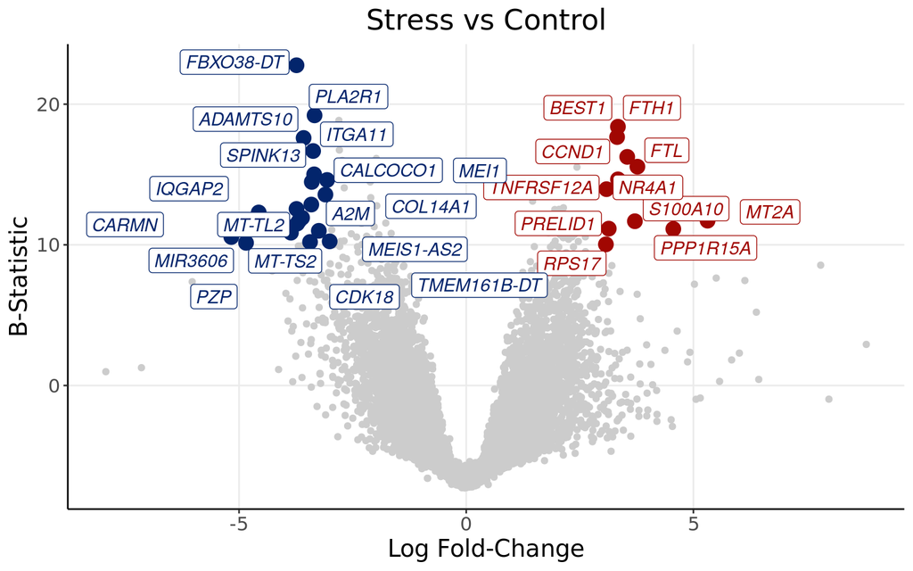

```r
upmarkers <- as.data.frame(DEGenes[DEGenes$logFC>3 & DEGenes$B>10,] )
downmarkers <- as.data.frame(DEGenes[DEGenes$logFC< -3 & DEGenes$B>10,] )

ggplot(data=DEGenes,
                 aes(x=logFC,
                     y=  B)) +
  geom_point(color="#CCCCCC")+
  theme_bw() + ylab("B-Statistic")+xlab("Log Fold-Change")+
  theme(axis.line = element_line(colour = "black"),
        panel.grid.minor = element_blank(),
        panel.border = element_blank(),
        panel.background = element_blank()) +
  ggtitle("Stress vs Control")+
  theme(plot.title = element_text(hjust = 0.5), plot.subtitle = element_text(hjust = 0.5)) +
  geom_point(data=upmarkers, aes(x=logFC, y=  B), color="#A10702",size=4)+
  geom_point(data=downmarkers, aes(x=logFC, y=  B), color="#03256C",size=4)+
  geom_label_repel(upmarkers[1:ndegs,] , mapping=aes(label=row.names(upmarkers)[1:ndegs]),size=4,point.padding=-0.5, color="#A10702",max.overlaps = 20, fontface="italic")+
  geom_label_repel(downmarkers[1:ndegs,] , mapping=aes(label=row.names(downmarkers)[1:ndegs]),size=4,point.padding=-0.5, color="#03256C",max.overlaps = 20, fontface="italic")+
  theme(text=element_text(size=15,  family="Arial MS"))
```

## Volcano Plot with Gene Length

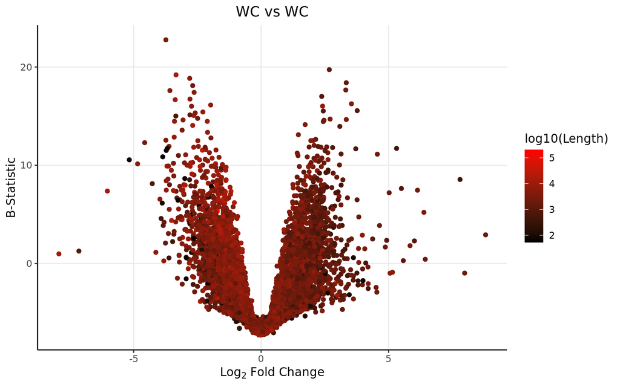

```r
DEGenes$Gene <- row.names(DEGenes)
colnames(genelength) <- c("Length","Gene")
DEGenes <- merge(DEGenes, genelength, by="Gene")

ggplot(data=DEGenes,
                 aes(x=logFC,
                     y=  B)) +
  geom_point(aes(color=log10(Length)))+
  theme_bw() +
  theme(axis.line = element_line(colour = "black"),
        panel.grid.minor = element_blank(),
        panel.border = element_blank(),
        panel.background = element_blank()) +
  ggtitle("WC vs WC")+ xlab(expression(Log[2] ~ Fold ~ Change)) + ylab("B-Statistic") +
  theme(plot.title = element_text(hjust = 0.5))  +
  scale_colour_gradient(low = "black", high = "red")+ theme(text=element_text(family = "Quicksand"))
```

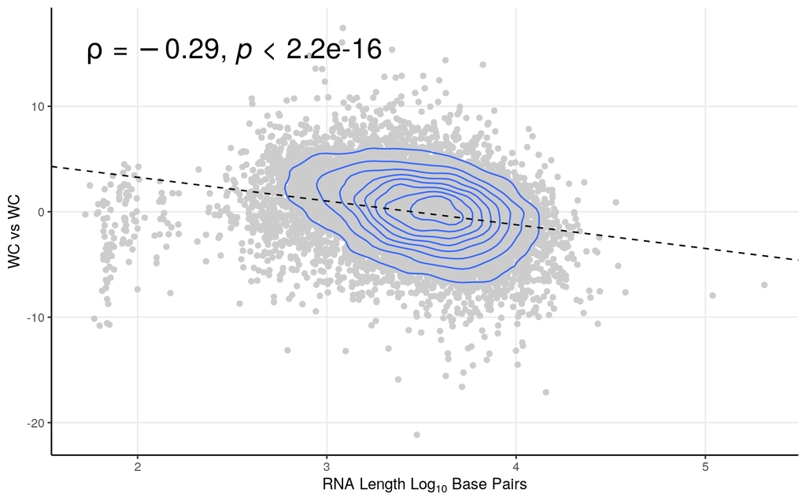

```r
smooth.SG <- lm(t~log10(Length), DEGenes)
liner.SG <- rstandard(smooth.SG)
DEGenes <-cbind(DEGenes, liner.SG)
colnames(DEGenes)[9] <- "Residuals"
row.names(DEGenes) <- DEGenes$Gene
linemarkers <- as.data.frame(DEGenes[abs(DEGenes$Residuals)>4,])

# Calculate the Spearman correlation coefficient
spearman_corr <- cor(DEGenes$t, log10(DEGenes$Length), method = "spearman")



ggplot(DEGenes, aes(y=t, x=log10(Length))) + geom_point(color="#CCCCCC", alpha=1) +   theme_bw()+ geom_density_2d()+
 ylab("WC vs WC") + xlab(expression(RNA ~ Length ~ Log[10] ~ Base ~ Pairs)) +
  theme(axis.line = element_line(colour = "black"),
        panel.grid.minor = element_blank(),
        panel.border = element_blank(),
        panel.background = element_blank()) +
  theme(plot.title = element_text(hjust = 0.5))  +
  geom_abline(slope=smooth.SG$coefficients[2], intercept = smooth.SG$coefficients[1], linetype = "dashed")+ stat_cor(method = "spearman", cor.coef.name = "rho",size=7)
```

As usual, stressed cells are smaller.

## GSEA Enrichment

Now that we have our genes of interest, it would also be interesting to see what are the **altered gene sets** between upregulated and downregulated transcripts from the above comparison. Therefore, lets perform a *Gene Set Enrichment Analysis*

```r
#for all genes
DEGenes <- DEGenes[order(DEGenes[,4]),]
gseatool <- DEGenes[,4]
gseatool <- as.data.frame(gseatool)
colnames(gseatool)[1] <- "t"
gseatool[,2] <- DEGenes$Gene
colnames(gseatool)[2] <- "Symbol"
gseatool <- gseatool[,c(2,1)]

vectorranks <- gseatool$t
names(vectorranks) <- gseatool$Symbol


#to load our pathways
hallmarks.gs <- msigdbr(species = "Homo sapiens", collection =  "H")

hallmarks.gsets <- hallmarks.gs %>% split(x = .$gene_symbol, f = .$gs_name)

for (set in names(hallmarks.gsets)){
  hallmarks.gsets[[set]] <- toupper(hallmarks.gsets[[set]])
}

hallmarks.res <- fgsea(pathways = hallmarks.gsets,
                       stats = vectorranks)
```

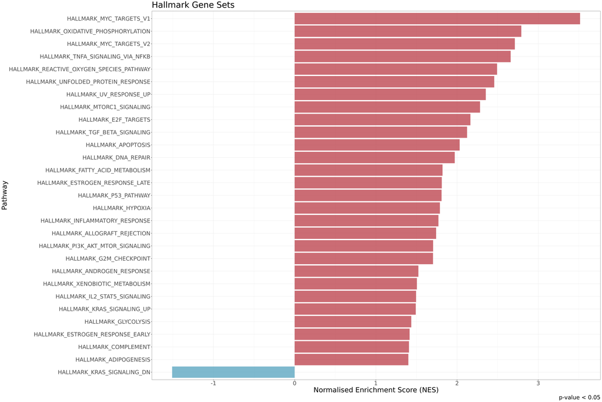

```r
hallmarks.res.tidy <- hallmarks.res %>%
  as_tibble() %>%
  arrange(desc(NES))

hallmarks.res.tidy %>%
  dplyr::select(-leadingEdge, -ES) %>%
  arrange(padj)

hallmark.sg.t <- hallmarks.res.tidy[,c(1,3,6)]
hallmark.sg.t <- as.data.frame(hallmark.sg.t)

#this small part is generic
thresh <- 0.05

#this one is no longer generic
data_to_plot <- hallmarks.res.tidy %>% filter(padj < thresh)

statvec <- c()
for (i in 1:nrow(data_to_plot)){
  if (data_to_plot[i,6] > 0){
    status <- "Upregulated"
  }
 else {
   status <- "Downregulated"
 }
statvec <- c(statvec, status)
}

data_to_plot$Status <- statvec

##-----HALMARK-----
gsea_plot_hall <- ggplot(data_to_plot, aes(reorder(pathway, NES), NES)) +
  geom_col(aes(fill= Status), alpha=0.75) + scale_fill_manual(values = c("#53A2BE","#BA3B46"), name = "Regulation Status", labels = c("Downregulated", "Upregulated"), breaks = c("Downregulated", "Upregulated")) +
  coord_flip() +
  labs(x="Pathway", y="Normalised Enrichment Score (NES)",
       title= "Hallmark Gene Sets",
       caption = paste0("p-value < ", thresh)) + theme(plot.title = element_text(hjust = 1)) +
  theme_bw() + theme(text=element_text(family = "Quicksand")) + theme(legend.position = "none")


gsea_plot_hall+
  theme(text=element_text(size=25,  family="Arial MS"))
```

# M6A Effect

## Linear Models

Now we must perform linear model fitting.

```r
sampnamer <- c(rep("SGkoin",3), rep("Nuc",2), rep("Nucin",2), rep("SGko",3), rep("SG",3), rep("SGin",3))

Stress <- c(rep("Yes",3), rep("No",2), rep("No",2), rep("Yes",3), rep("Yes",3), rep("Yes",3))

Sample <- c(rep("WC",3), rep("Nuc",2), rep("WC",2), rep("SG",3), rep("SG",3), rep("WC",3))

m6A <- c(rep("KO",3), rep("WT",2), rep("WT",2), rep("KO",3), rep("WT",3), rep("WT",3))

mm <- model.matrix(~1+Stress+Sample*m6A)

mm[,2] <- ifelse(mm[,2] == 1, 0.5, -0.5)
mm[,3] <- ifelse(mm[,3] == 1, 0.5, -0.5)
mm[,4] <- ifelse(mm[,4] == 1, 0.5, -0.5)
mm[,5] <- ifelse(mm[,5] == 1, 0.5, -0.5)
mm[,6] <- mm[,5]*mm[,3]*-1


fitted <- lmFit(y, mm)
```

```
## Coefficients not estimable: SampleWC:m6AWT
```

```r
head(coef(fitted))
```

```
##         (Intercept)  StressYes   SampleSG   SampleWC     m6AWT SampleSG:m6AWT
## 7SK        8.986719 -0.1138512  0.7131757 -0.7077593 2.7038892      3.8129566
## A2M        7.676887 -3.4755249  3.1122199 -0.4459891 0.4588670      0.3790052
## A2M-AS1    3.103861 -2.2741224  1.5955229  0.4197889 0.5059565     -0.5354175
## A4GALT     4.435025  0.3780739 -0.6219819 -0.4661879 0.3474570      0.7346625
## AAAS       5.819038 -0.3512875 -0.6270486 -0.3308896 0.3945052      0.1340180
## AACS       5.611022 -0.5550348  0.7861659 -0.6232066 0.1917732      0.8501793
##         SampleWC:m6AWT
## 7SK                 NA
## A2M                 NA
## A2M-AS1             NA
## A4GALT              NA
## AAAS                NA
## AACS                NA
```

```r
#use empirical bayes smoothing of standard erros (shrinks extreme standard erros)
tmp <- eBayes(fitted)
top.table <- topTable(tmp,6, sort.by = "logFC", n = Inf)
DEGenes <- top.table
ndegs=20
```

## Volcano Plot

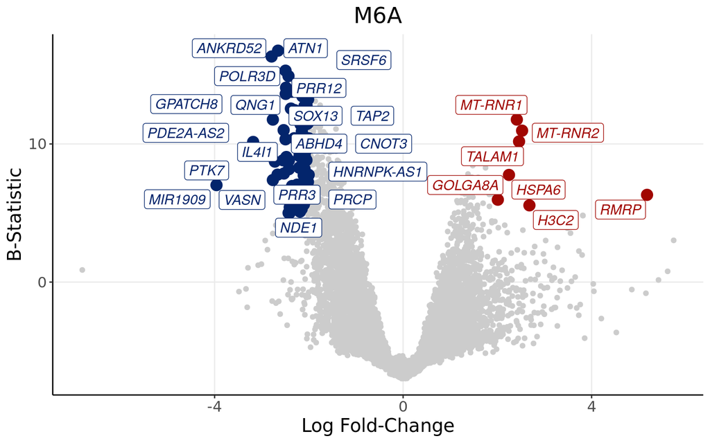

```r
upmarkers <- as.data.frame(DEGenes[DEGenes$logFC>2 & DEGenes$B>5,] )
downmarkers <- as.data.frame(DEGenes[DEGenes$logFC< -2 & DEGenes$B>5,] )

ggplot(data=DEGenes,
                 aes(x=logFC,
                     y=  B)) +
  geom_point(color="#CCCCCC")+
  theme_bw() + ylab("B-Statistic")+xlab("Log Fold-Change")+
  theme(axis.line = element_line(colour = "black"),
        panel.grid.minor = element_blank(),
        panel.border = element_blank(),
        panel.background = element_blank()) +
  ggtitle("M6A")+
  theme(plot.title = element_text(hjust = 0.5), plot.subtitle = element_text(hjust = 0.5)) +
  geom_point(data=upmarkers, aes(x=logFC, y=  B), color="#A10702",size=4)+
  geom_point(data=downmarkers, aes(x=logFC, y=  B), color="#03256C",size=4)+
  geom_label_repel(upmarkers[1:ndegs,] , mapping=aes(label=row.names(upmarkers)[1:ndegs]),size=4,point.padding=-0.5, color="#A10702",max.overlaps = 20, fontface="italic")+
  geom_label_repel(downmarkers[1:ndegs,] , mapping=aes(label=row.names(downmarkers)[1:ndegs]),size=4,point.padding=-0.5, color="#03256C",max.overlaps = 20, fontface="italic")+
  theme(text=element_text(size=15,  family="Arial MS"))
```

## Volcano Plot with Gene Length

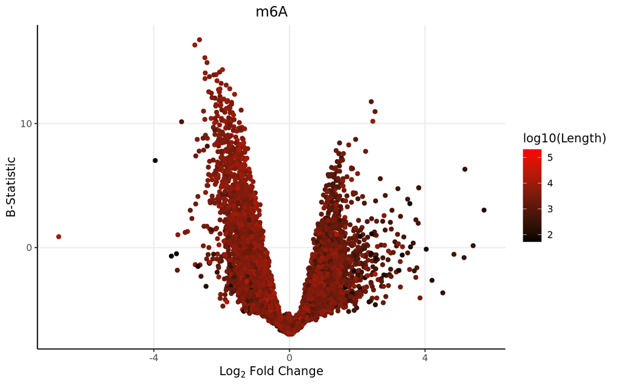

```r
DEGenes$Gene <- row.names(DEGenes)
colnames(genelength) <- c("Length","Gene")
DEGenes <- merge(DEGenes, genelength, by="Gene")

ggplot(data=DEGenes,
                 aes(x=logFC,
                     y=  B)) +
  geom_point(aes(color=log10(Length)))+
  theme_bw() +
  theme(axis.line = element_line(colour = "black"),
        panel.grid.minor = element_blank(),
        panel.border = element_blank(),
        panel.background = element_blank()) +
  ggtitle("m6A")+ xlab(expression(Log[2] ~ Fold ~ Change)) + ylab("B-Statistic") +
  theme(plot.title = element_text(hjust = 0.5))  +
  scale_colour_gradient(low = "black", high = "red")+ theme(text=element_text(family = "Quicksand"))
```

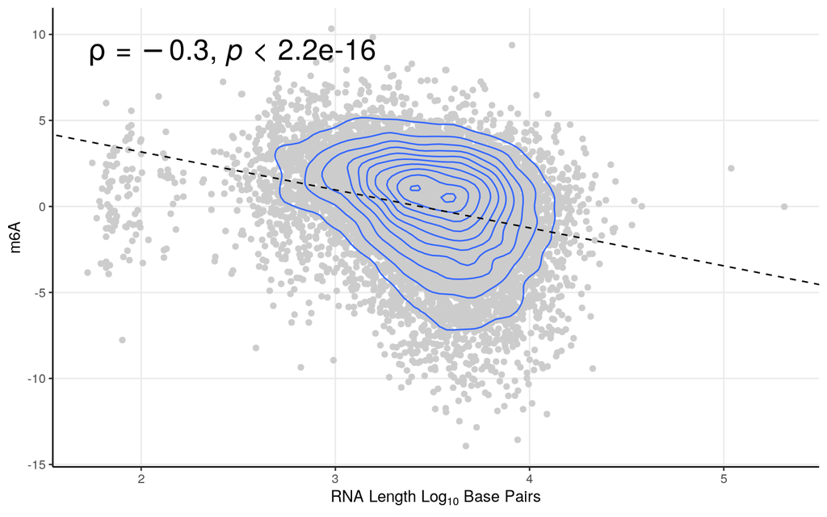

```r
smooth.SG <- lm(t~log10(Length), DEGenes)
liner.SG <- rstandard(smooth.SG)
DEGenes <-cbind(DEGenes, liner.SG)
colnames(DEGenes)[9] <- "Residuals"
row.names(DEGenes) <- DEGenes$Gene
linemarkers <- as.data.frame(DEGenes[abs(DEGenes$Residuals)>4,])

# Calculate the Spearman correlation coefficient
spearman_corr <- cor(DEGenes$t, log10(DEGenes$Length), method = "spearman")



ggplot(DEGenes, aes(y=t, x=log10(Length))) + geom_point(color="#CCCCCC", alpha=1) +   theme_bw()+ geom_density_2d()+
 ylab("m6A") + xlab(expression(RNA ~ Length ~ Log[10] ~ Base ~ Pairs)) +
  theme(axis.line = element_line(colour = "black"),
        panel.grid.minor = element_blank(),
        panel.border = element_blank(),
        panel.background = element_blank()) +
  theme(plot.title = element_text(hjust = 0.5))  +
  geom_abline(slope=smooth.SG$coefficients[2], intercept = smooth.SG$coefficients[1], linetype = "dashed")+ stat_cor(method = "spearman", cor.coef.name = "rho",size=7)
```

## GSEA Enrichment

Now that we have our genes of interest, it would also be interesting to see what are the **altered gene sets** between upregulated and downregulated transcripts from the above comparison. Therefore, lets perform a *Gene Set Enrichment Analysis*

```r
#for all genes
DEGenes <- DEGenes[order(DEGenes[,4]),]
gseatool <- DEGenes[,4]
gseatool <- as.data.frame(gseatool)
colnames(gseatool)[1] <- "t"
gseatool[,2] <- DEGenes$Gene
colnames(gseatool)[2] <- "Symbol"
gseatool <- gseatool[,c(2,1)]

vectorranks <- gseatool$t
names(vectorranks) <- gseatool$Symbol


#to load our pathways
hallmarks.gs <- msigdbr(species = "Homo sapiens", collection =  "H")

hallmarks.gsets <- hallmarks.gs %>% split(x = .$gene_symbol, f = .$gs_name)

for (set in names(hallmarks.gsets)){
  hallmarks.gsets[[set]] <- toupper(hallmarks.gsets[[set]])
}

hallmarks.res <- fgsea(pathways = hallmarks.gsets,
                       stats = vectorranks)
```

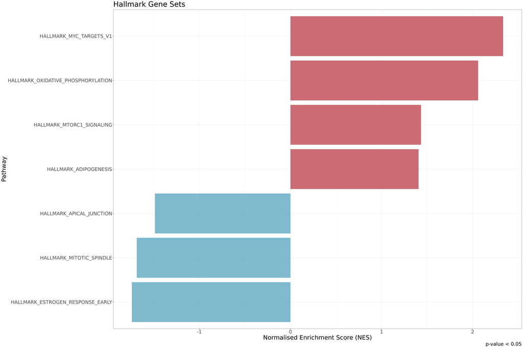

```r
hallmarks.res.tidy <- hallmarks.res %>%
  as_tibble() %>%
  arrange(desc(NES))

hallmarks.res.tidy %>%
  dplyr::select(-leadingEdge, -ES) %>%
  arrange(padj)

hallmark.sg.t <- hallmarks.res.tidy[,c(1,3,6)]
hallmark.sg.t <- as.data.frame(hallmark.sg.t)

#this small part is generic
thresh <- 0.05

#this one is no longer generic
data_to_plot <- hallmarks.res.tidy %>% filter(padj < thresh)

statvec <- c()
for (i in 1:nrow(data_to_plot)){
  if (data_to_plot[i,6] > 0){
    status <- "Upregulated"
  }
 else {
   status <- "Downregulated"
 }
statvec <- c(statvec, status)
}

data_to_plot$Status <- statvec

##-----HALMARK-----
gsea_plot_hall <- ggplot(data_to_plot, aes(reorder(pathway, NES), NES)) +
  geom_col(aes(fill= Status), alpha=0.75) + scale_fill_manual(values = c("#53A2BE","#BA3B46"), name = "Regulation Status", labels = c("Downregulated", "Upregulated"), breaks = c("Downregulated", "Upregulated")) +
  coord_flip() +
  labs(x="Pathway", y="Normalised Enrichment Score (NES)",
       title= "Hallmark Gene Sets",
       caption = paste0("p-value < ", thresh)) + theme(plot.title = element_text(hjust = 1)) +
  theme_bw() + theme(text=element_text(family = "Quicksand")) + theme(legend.position = "none")


gsea_plot_hall+
  theme(text=element_text(size=25,  family="Arial MS"))
```

# SG (proper)

## Linear Models

```r
sampnamer <- c(rep("SGkoin",3), rep("Nuc",2), rep("Nucin",2), rep("SGko",3), rep("SG",3), rep("SGin",3))

Stress <- c(rep("Yes",3), rep("No",2), rep("No",2), rep("Yes",3), rep("Yes",3), rep("Yes",3))

Sample <- c(rep("WC",3), rep("Nuc",2), rep("WC",2), rep("SG",3), rep("SG",3), rep("WC",3))

m6A <- c(rep("KO",3), rep("WT",2), rep("WT",2), rep("KO",3), rep("WT",3), rep("WT",3))

metadata <- data.frame(Stress=Stress,Sample=Sample, Metil=m6A)


batch_cols <- c("Stress", "Metil")
metadata_cols <- c("Sample")
mmbatch <- model.matrix(reformulate(paste0("~0 + ",paste0( batch_cols,collapse = " + "))), data=metadata)
mmkeep <- model.matrix(reformulate(paste0("~0 + ",paste0( metadata_cols,collapse =  "+" ))), data=metadata)
mm <- cbind(mmkeep,mmbatch)
D0 <- DGEList(2^y$E) #senescence_normcounts
D0 <- calcNormFactors(D0)
y <- voom(D0, mm, plot = F)
```

```
## Coefficients not estimable: StressYes
```

```r
fit <- lmFit(y, mm)
```

```
## Coefficients not estimable: StressYes
```

```
## Coefficients not estimable: StressYes
```

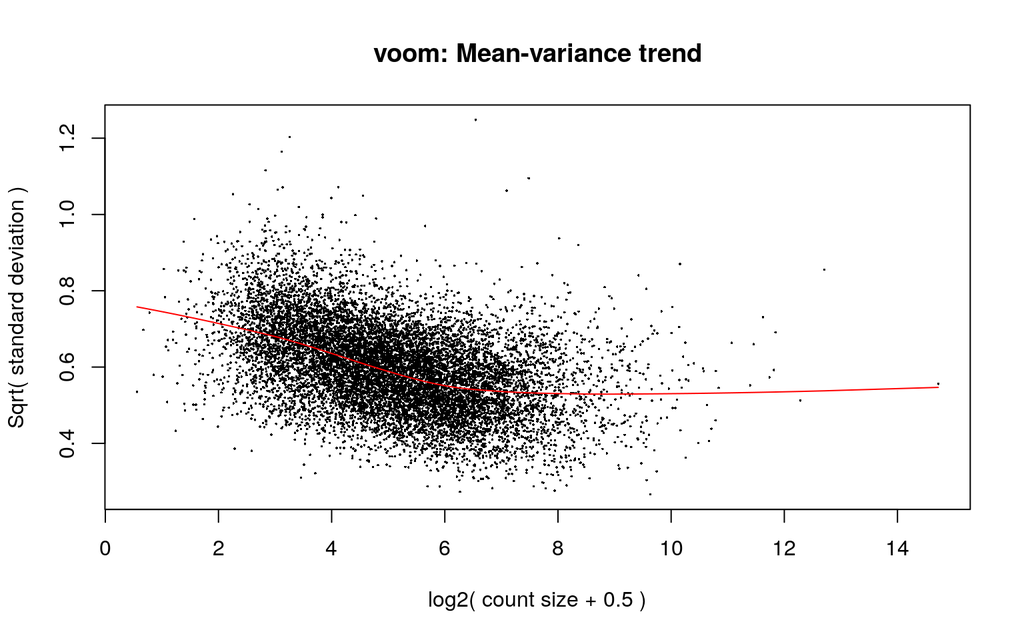

```r
beta <- fit$coefficients[,-(1:ncol(mmkeep)),drop=FALSE]
#beta <- fit$coefficients
beta[is.na(beta)] <- 0
corrcounts_v1 <- as.matrix(y$E) - beta %*% t(mmbatch)
offset <- apply(corrcounts_v1,1,min) - apply(y$E,1,min)
corrcounts_v1 <- as.data.frame(corrcounts_v1-offset)
corrcounts_v1 <- 2^corrcounts_v1
y <- voom(corrcounts_v1, mm, plot = T)
```

```r
mm <- model.matrix(~0+Sample)

fitted <- lmFit(y, mm)
head(coef(fitted))
```

```
##         SampleNuc SampleSG SampleWC
## 7SK      7.718364 8.431448 7.131633
## A2M      4.763599 7.777910 4.413263
## A2M-AS1  1.606154 2.877577 2.065763
## A4GALT   5.560520 4.924173 5.193784
## AAAS     6.485338 5.874133 6.277276
## AACS     5.394965 6.155719 4.900834
```

```r
#next we measure contrasts between groups (log-fold change is obtained from these fitted linear models)
contr<- makeContrasts(SampleSG            - SampleWC              , levels = mm)


#next we estimate the contrast for each gene
tmp <- contrasts.fit(fitted, contr)


#use empirical bayes smoothing of standard erros (shrinks extreme standard erros)
tmp <- eBayes(tmp)
top.table <- topTable(tmp, sort.by = "logFC", n = Inf)
DEGenes <- top.table
ndegs=20
```

## Volcano Plot

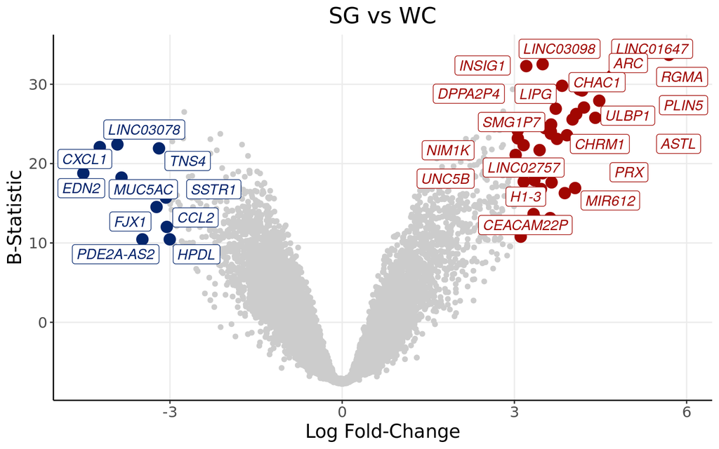

```r
write.table(x = DEGenes,
          file = "~/Projects/StressGranules/SGPAPER/RealSGs/Photon.txt", sep="\t", col.names = TRUE, row.names = TRUE, quote=FALSE)

upmarkers <- as.data.frame(DEGenes[DEGenes$logFC>3 & DEGenes$B>10,] )
downmarkers <- as.data.frame(DEGenes[DEGenes$logFC< -3 & DEGenes$B>10,] )

ggplot(data=DEGenes,
                 aes(x=logFC,
                     y=  B)) +
  geom_point(color="#CCCCCC")+
  theme_bw() + ylab("B-Statistic")+xlab("Log Fold-Change")+
  theme(axis.line = element_line(colour = "black"),
        panel.grid.minor = element_blank(),
        panel.border = element_blank(),
        panel.background = element_blank()) +
  ggtitle("SG vs WC")+
  theme(plot.title = element_text(hjust = 0.5), plot.subtitle = element_text(hjust = 0.5)) +
  geom_point(data=upmarkers, aes(x=logFC, y=  B), color="#A10702",size=4)+
  geom_point(data=downmarkers, aes(x=logFC, y=  B), color="#03256C",size=4)+
  geom_label_repel(upmarkers[1:ndegs,] , mapping=aes(label=row.names(upmarkers)[1:ndegs]),size=4,point.padding=-0.5, color="#A10702",max.overlaps = 20, fontface="italic")+
  geom_label_repel(downmarkers[1:ndegs,] , mapping=aes(label=row.names(downmarkers)[1:ndegs]),size=4,point.padding=-0.5, color="#03256C",max.overlaps = 20, fontface="italic")+
  theme(text=element_text(size=15,  family="Arial MS"))
```

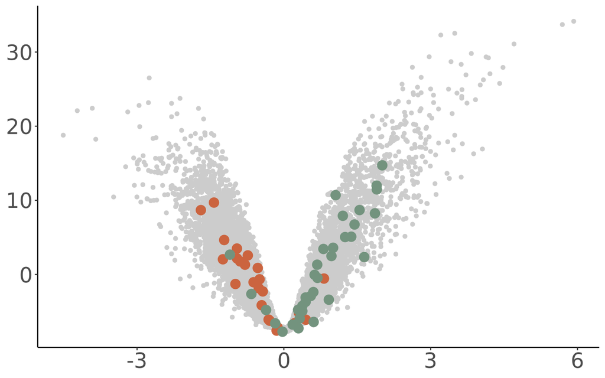

```r
MitoGenes <- fread("~/MitoGenes.txt")[[1]]
MitoData <- DEGenes[rownames(DEGenes) %in% MitoGenes, ]
NucGenes <- fread("~/rnalocate_mito_filt.csv")[[1]]
NucData <- DEGenes[rownames(DEGenes) %in% NucGenes, ]
(m <- ggplot(data=DEGenes,
                 aes(x=logFC,
                     y=B)) +
  geom_point(color="#CCCCCC") +
  geom_point(data=NucData, aes(x=logFC, y=B), color="#CB643F", size=4) +
  geom_point(data=MitoData, aes(x=logFC, y=B), color="#73937E", size=4) +
  ylab("B-Statistic") +
  xlab(expression(Log[2]~"Fold-Change")) +
  theme(
    axis.line = element_line(colour = "black"),
    panel.grid.major = element_blank(),   # remove major gridlines
    panel.grid.minor = element_blank(),   # remove minor gridlines
    panel.border = element_blank(),
    panel.background = element_blank(),
    axis.title = element_blank()
  ) +
  theme(plot.title = element_text(hjust = 0.5), plot.subtitle = element_text(hjust = 0.5)) +
  theme(text=element_text(size=25, family="Arial MS")))
```

```r
png("~/Projects/StressGranules/SGPAPER/Images/PNG/RajaMito.png", width = 7, height=6, units = "in", res=300)
m
dev.off()
```

# MA Plot

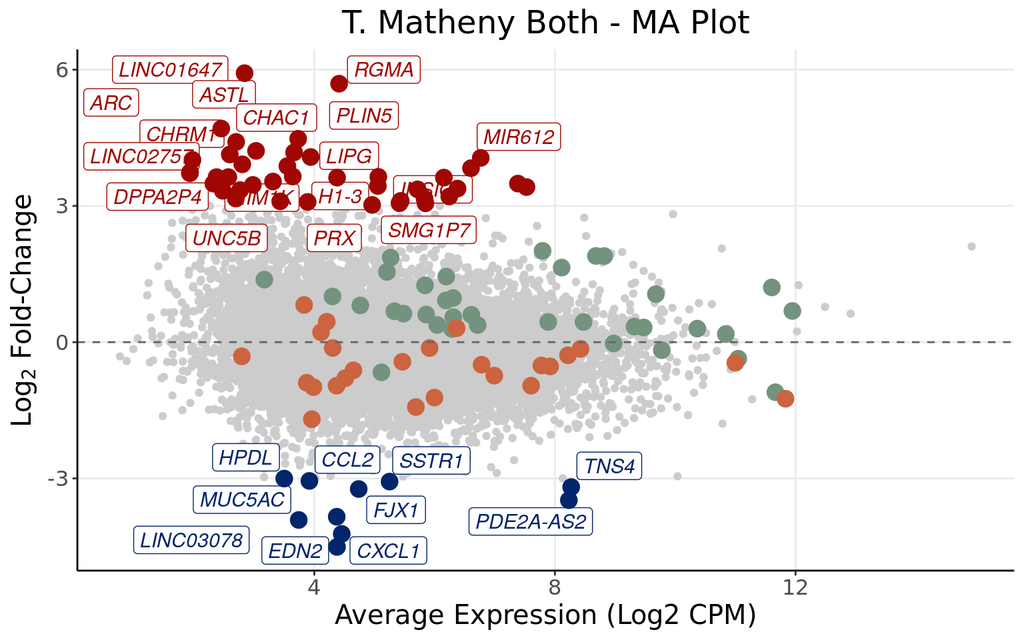

```r
# MA plot: mean expression (x) vs logFC (y), same highlighting scheme as the volcano

ggplot(data=DEGenes,
                 aes(x=AveExpr,
                     y=logFC)) +
  geom_point(color="#CCCCCC") +
  geom_point(data=MitoData, aes(x=AveExpr, y=logFC), color="#73937E", size=4) +
  geom_point(data=NucData, aes(x=AveExpr, y=logFC), color="#CB643F", size=4) +
  geom_hline(yintercept = 0, linetype="dashed", color="grey40") +
  theme_bw() + ylab(expression(Log[2]~"Fold-Change")) + xlab("Average Expression (Log2 CPM)") +
  theme(axis.line = element_line(colour = "black"),
        panel.grid.minor = element_blank(),
        panel.border = element_blank(),
        panel.background = element_blank()) +
  ggtitle("T. Matheny Both - MA Plot") +
  theme(plot.title = element_text(hjust = 0.5), plot.subtitle = element_text(hjust = 0.5)) +
  geom_label_repel(upmarkers[1:ndegs,], mapping=aes(x=AveExpr, y=logFC, label=row.names(upmarkers)[1:ndegs]), size=4, point.padding=-0.5, color="#A10702", max.overlaps=20, fontface="italic") +
  geom_label_repel(downmarkers[1:ndegs,], mapping=aes(x=AveExpr, y=logFC, label=row.names(downmarkers)[1:ndegs]), size=4, point.padding=-0.5, color="#03256C", max.overlaps=20, fontface="italic") +
  geom_point(data=upmarkers, aes(x=AveExpr, y=logFC), color="#A10702", size=4) +
  geom_point(data=downmarkers, aes(x=AveExpr, y=logFC), color="#03256C", size=4) +
  theme(text=element_text(size=15, family="Arial MS"))
```

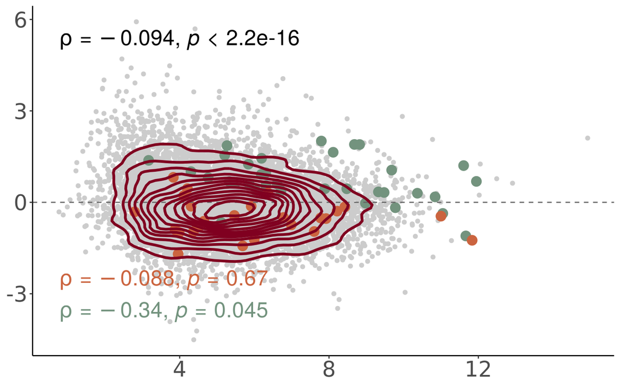

```r
# Publication-style version, stripped of axis titles, matching your "m" plot
(ma <- ggplot(data=DEGenes,
                 aes(x=AveExpr,
                     y=logFC)) +
  geom_point(color="#CCCCCC") +
  geom_point(data=MitoData, aes(x=AveExpr, y=logFC), color="#73937E", size=4) +
  geom_point(data=NucData, aes(x=AveExpr, y=logFC), color="#CB643F", size=4) +
  geom_hline(yintercept = 0, linetype="dashed", color="grey40") +
  ylab(expression(Log[2]~"Fold-Change")) +
  xlab("Average Expression (Log2 CPM)") + geom_density2d(color = "#800020", size = 1.2) + stat_cor(method = "spearman", cor.coef.name = "rho", size=7)+
  stat_cor(data = MitoData, aes(x=AveExpr, y=logFC), method = "spearman",
           cor.coef.name = "rho", size=7, color = "#73937E", label.y.npc = 0.1) +
  stat_cor(data = NucData, aes(x=AveExpr, y=logFC), method = "spearman",
           cor.coef.name = "rho", size=7, color = "#CB643F", label.y.npc = 0.2) +
  theme(
    axis.line = element_line(colour = "black"),
    panel.grid.major = element_blank(),
    panel.grid.minor = element_blank(),
    panel.border = element_blank(),
    panel.background = element_blank(),
    axis.title = element_blank()
  ) +
  theme(plot.title = element_text(hjust = 0.5), plot.subtitle = element_text(hjust = 0.5)) +
  theme(text=element_text(size=25, family="Arial MS")))
```

```r
png("~/Projects/StressGranules/SGPAPER/Images/PNG/RajaMito_MA.png", width = 7, height=6, units = "in", res=300)
ma
dev.off()
```

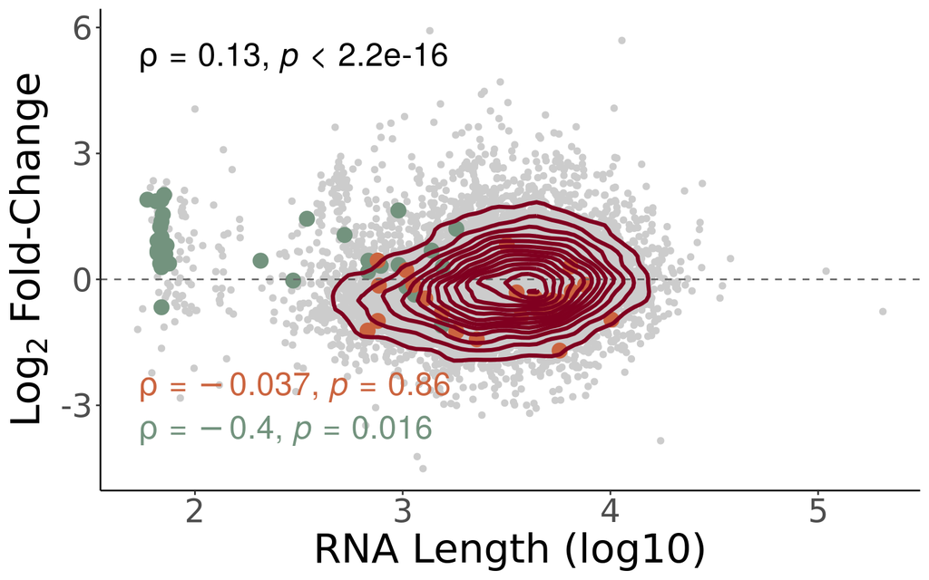

```r
MitoGenes <- fread("~/MitoGenes.txt")[[1]]

genelength <- read.csv("~/Projects/StressGranules/SG_Transcriptome/RP_Data_2021/TrimmedSamples/alignment_STAR/TranscriptLenght.txt", header=T)
genelength <- subset(genelength, Ensembl.Canonical==1)
genelength <- subset(genelength, Gene.name!="")
genelength <- genelength %>%
  group_by(Gene.name) %>%
  slice(which.max(Transcript.length..including.UTRs.and.CDS.)) %>%
  ungroup()
genelength <- genelength[,-c(2,3)]
colnames(genelength) <- c("Length", "Gene")

genelength$Cromo <- ifelse(genelength$Gene %in% MitoGenes, "Mito", "Other")

# Apply the length-based weight formula
genelength$S <- ifelse(
  genelength$Cromo == "Mito",
  (genelength$Length)^(1/3) * 3.23e-11 + 1.17e-9,   # Formula for mitochondrial RNAs
  (genelength$Length)^(1/3) * 6.09e-11 + 3.88e-10    # Formula for other RNAs
)
DEGenes$Gene <- row.names(DEGenes)
DEGenes <- merge(DEGenes, genelength, by="Gene")
MitoGenes <- fread("~/MitoGenes.txt")[[1]]
MitoData <- DEGenes[DEGenes$Gene %in% MitoGenes, ]
NucGenes <- fread("~/rnalocate_mito_filt.csv")[[1]]
NucData <- DEGenes[DEGenes$Gene %in% NucGenes, ]

# Publication-style version, stripped of axis titles, matching your "m" plot
(ma <- ggplot(data=DEGenes,
                 aes(x=log10(Length),
                     y=logFC)) +
  geom_point(color="#CCCCCC") +
  geom_point(data=MitoData, aes(x=log10(Length), y=logFC), color="#73937E", size=4) +
  geom_point(data=NucData, aes(x=log10(Length), y=logFC), color="#CB643F", size=4) +
  geom_hline(yintercept = 0, linetype="dashed", color="grey40") +
  ylab(expression(Log[2]~"Fold-Change")) + geom_density2d(color = "#800020", size = 1.2) + stat_cor(method = "spearman", cor.coef.name = "rho", size=7)+
  stat_cor(data = MitoData, aes(x=log10(Length), y=logFC), method = "spearman",
           cor.coef.name = "rho", size=7, color = "#73937E", label.y.npc = 0.1) +
  stat_cor(data = NucData, aes(x=log10(Length), y=logFC), method = "spearman",
           cor.coef.name = "rho", size=7, color = "#CB643F", label.y.npc = 0.2) +
  xlab("RNA Length (log10)") +
  theme(
    axis.line = element_line(colour = "black"),
    panel.grid.major = element_blank(),
    panel.grid.minor = element_blank(),
    panel.border = element_blank(),
    panel.background = element_blank()
  ) +
  theme(plot.title = element_text(hjust = 0.5), plot.subtitle = element_text(hjust = 0.5)) +
  theme(text=element_text(size=25, family="Arial MS")))
```

```r
png("~/Projects/StressGranules/SGPAPER/Images/PNG/RajaMito_MA_length.png", width = 7, height=6, units = "in", res=300)
ma
dev.off()
```

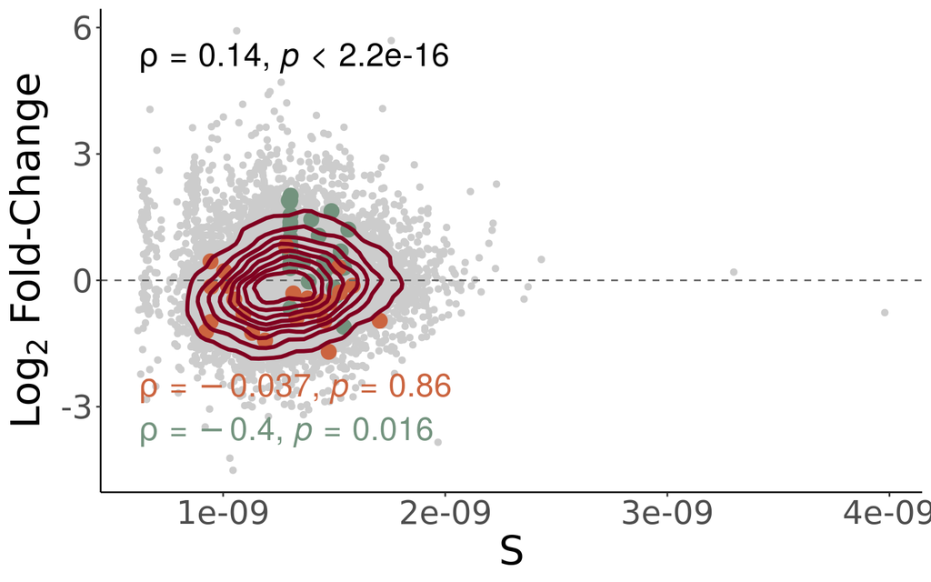

```r
# Publication-style version, stripped of axis titles, matching your "m" plot
(ma <- ggplot(data=DEGenes,
                 aes(x=(S),
                     y=logFC)) +
  geom_point(color="#CCCCCC") +
  geom_point(data=MitoData, aes(x=(S), y=logFC), color="#73937E", size=4) +
  geom_point(data=NucData, aes(x=(S), y=logFC), color="#CB643F", size=4) +
  geom_hline(yintercept = 0, linetype="dashed", color="grey40") +
  ylab(expression(Log[2]~"Fold-Change")) + geom_density2d(color = "#800020", size = 1.2) + stat_cor(method = "spearman", cor.coef.name = "rho", size=7)+
  stat_cor(data = MitoData, aes(x=S, y=logFC), method = "spearman",
           cor.coef.name = "rho", size=7, color = "#73937E", label.y.npc = 0.1) +
  stat_cor(data = NucData, aes(x=S, y=logFC), method = "spearman",
           cor.coef.name = "rho", size=7, color = "#CB643F", label.y.npc = 0.2) +
  xlab("S") +
  theme(
    axis.line = element_line(colour = "black"),
    panel.grid.major = element_blank(),
    panel.grid.minor = element_blank(),
    panel.border = element_blank(),
    panel.background = element_blank()
  ) +
  theme(plot.title = element_text(hjust = 0.5), plot.subtitle = element_text(hjust = 0.5)) +
  theme(text=element_text(size=25, family="Arial MS")))
```

```r
png("~/Projects/StressGranules/SGPAPER/Images/PNG/RajaMito_MA_S.png", width = 7, height=6, units = "in", res=300)
ma
dev.off()
```

# Violins

```r
## Signature Violin (Mito/Nuc) - SG vs WC

library(data.table)
library(dplyr)
library(ggplot2)
library(rstatix)
# Restrict to just the SG and WC samples (exclude the Nuc fraction samples)
sgwc_idx <- which(Sample %in% c("SG", "WC"))

expression.df <- y$E[, sgwc_idx]
cond <- factor(Sample[sgwc_idx], levels = c("WC", "SG"))

custom_palette <- c(
  "WC" = "#399e5a",
  "SG" = "#769fca"
)

# ── 1. Gene sets already loaded earlier in the script (MitoGenes, NucGenes) ──
mito_genes_present <- MitoGenes[MitoGenes %in% rownames(expression.df)]
nuc_genes_present  <- NucGenes[NucGenes %in% rownames(expression.df)]
cat(length(mito_genes_present), "Mito genes found in expression matrix\n")
```

```
## 35 Mito genes found in expression matrix
```

```r
cat(length(nuc_genes_present), "Nuc genes found in expression matrix\n")
```

```
## 25 Nuc genes found in expression matrix
```

```r
# ── 2. Rank all genes per sample (1 = least expressed) ───────────────────────
rank_matrix <- apply(expression.df, 2, function(x) rank(x, ties.method = "average"))
rank_matrix <- as.data.frame(rank_matrix)

# ── 3. Compute a rank-sum score per sample, one gene set at a time ───────────
compute_score <- function(genes, rank_matrix, n_total) {
  colSums(rank_matrix[genes, , drop = FALSE]) / n_total
}

mito_score <- compute_score(mito_genes_present, rank_matrix, nrow(expression.df))
nuc_score  <- compute_score(nuc_genes_present, rank_matrix, nrow(expression.df))

# ── 4. Assemble plot dataframe, long format across both gene sets ────────────
score_df <- rbind(
  data.frame(Sample = colnames(expression.df), Score = as.numeric(mito_score),
             Condition = cond, GeneSet = "Mito"),
  data.frame(Sample = colnames(expression.df), Score = as.numeric(nuc_score),
             Condition = cond, GeneSet = "Nuc")
)

# ── 5. Statistics per gene set: one-way ANOVA (equivalent to t-test, 2 groups) ──
stat_labels <- score_df %>%
  group_by(GeneSet) %>%
  group_modify(~{
    aov_res  <- aov(Score ~ Condition, data = .x)
    aov_tidy <- summary(aov_res)
    p_raw  <- aov_tidy[[1]][["Pr(>F)"]][1]
    p_adj  <- p.adjust(p_raw, method = "BH")
    ss_between <- aov_tidy[[1]][["Sum Sq"]][1]
    ss_total   <- sum(aov_tidy[[1]][["Sum Sq"]])
    eta_sq     <- ss_between / ss_total
    cohens_f   <- sqrt(eta_sq / (1 - eta_sq))
    data.frame(
      label = paste0("Cohen's f = ", round(cohens_f, 3),
                      "\nadj. p = ", formatC(p_adj, format = "e", digits = 2))
    )
  })

# ── 6. Plot ───────────────────────────────────────────────────────────────────
vilsigplot <- ggplot(score_df, aes(x = Condition, y = Score, fill = Condition)) +
  geom_violin(colour = "black", alpha = 0.6, trim = FALSE) +
  geom_point(
    position = position_jitter(width = 0.1),
    alpha    = 0.7,
    size     = 1.5
  ) +
  stat_summary(fun = mean,   geom = "point", shape = 18,
               size = 3, colour = "black") +
  stat_summary(fun = median, geom = "point", shape = 17,
               size = 3, colour = "black") +
  geom_text(
    data  = stat_labels,
    aes(x = -Inf, y = Inf, label = label),
    hjust = -0.05, vjust = 1.2,
    size  = 4, fontface = "bold", lineheight = 1.1,
    inherit.aes = FALSE
  ) +
  facet_wrap(~GeneSet, scales = "free_y") +
  scale_fill_manual(values = custom_palette) +
  labs(
    x     = "Fraction",
    y     = "Signature Score (Rank Sum)",
    title = "Mitochondrial vs Nuclear-Localized Gene Scores - SG vs WC"
  ) +
  theme_bw() +
  theme(
    plot.title      = element_text(hjust = 0.5, size = 14, face = "bold"),
    axis.text.x     = element_text(size = 12),
    strip.text      = element_text(size = 12, face = "bold"),
    legend.position = "none"
  )

png("~/Projects/StressGranules/SGPAPER/Images/PNG/Raja_MitoSigs.png", width = 14, height=6, units = "in", res=300)
vilsigplot
dev.off()
```

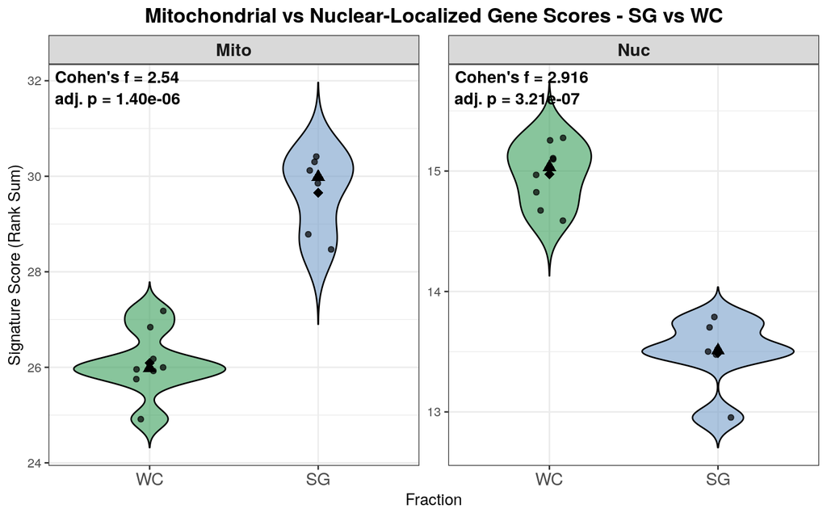

```r
vilsigplot
```

## Volcano Plot with Gene Length

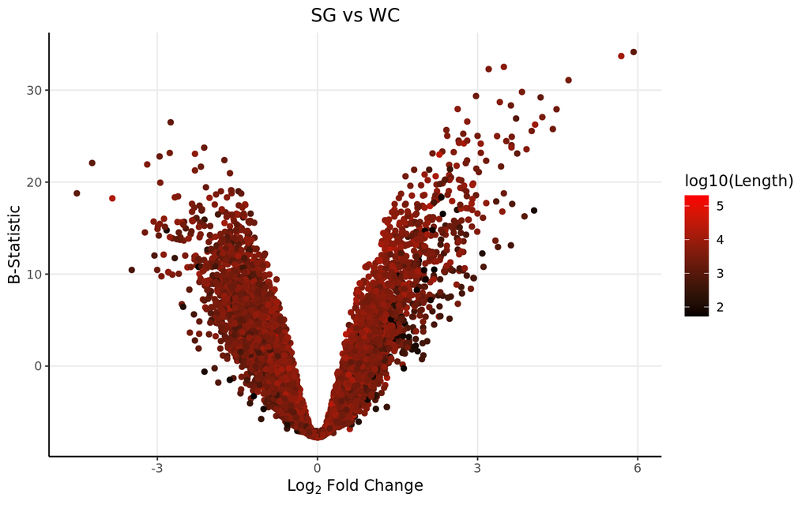

```r
ggplot(data=DEGenes,
                 aes(x=logFC,
                     y=  B)) +
  geom_point(aes(color=log10(Length)))+
  theme_bw() +
  theme(axis.line = element_line(colour = "black"),
        panel.grid.minor = element_blank(),
        panel.border = element_blank(),
        panel.background = element_blank()) +
  ggtitle("SG vs WC")+ xlab(expression(Log[2] ~ Fold ~ Change)) + ylab("B-Statistic") +
  theme(plot.title = element_text(hjust = 0.5))  +
  scale_colour_gradient(low = "black", high = "red")+ theme(text=element_text(family = "Quicksand"))
```

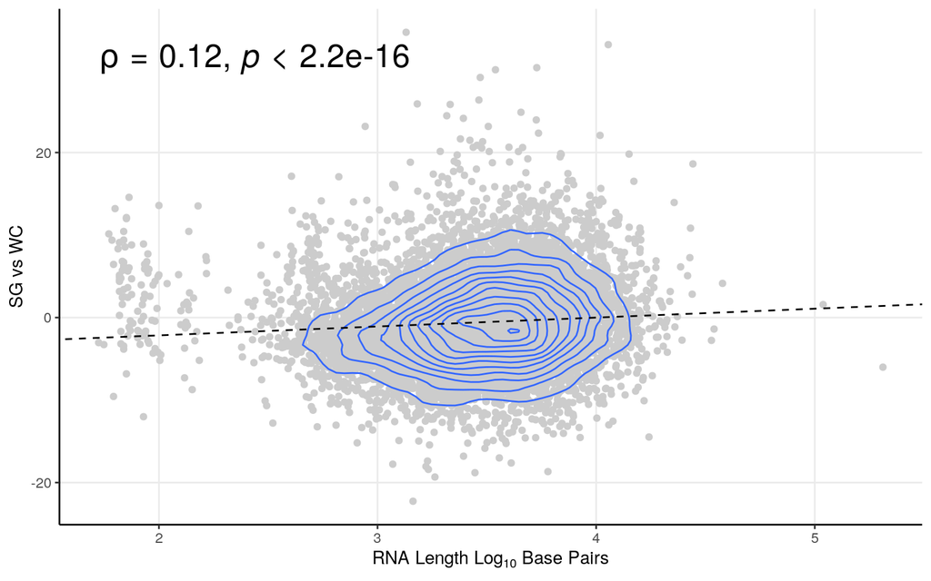

```r
smooth.SG <- lm(t~log10(Length), DEGenes)
liner.SG <- rstandard(smooth.SG)
DEGenes <-cbind(DEGenes, liner.SG)
colnames(DEGenes)[11] <- "Residuals"
row.names(DEGenes) <- DEGenes$Gene
linemarkers <- as.data.frame(DEGenes[abs(DEGenes$Residuals)>4,])

# Calculate the Spearman correlation coefficient
spearman_corr <- cor(DEGenes$t, log10(DEGenes$Length), method = "spearman")



ggplot(DEGenes, aes(y=t, x=log10(Length))) + geom_point(color="#CCCCCC", alpha=1) +   theme_bw()+ geom_density_2d()+
 ylab("SG vs WC") + xlab(expression(RNA ~ Length ~ Log[10] ~ Base ~ Pairs)) +
  theme(axis.line = element_line(colour = "black"),
        panel.grid.minor = element_blank(),
        panel.border = element_blank(),
        panel.background = element_blank()) +
  theme(plot.title = element_text(hjust = 0.5))  +
  geom_abline(slope=smooth.SG$coefficients[2], intercept = smooth.SG$coefficients[1], linetype = "dashed")+ stat_cor(method = "spearman", cor.coef.name = "rho",size=7)
```

## Expression Graphs (Extra QC)

As an added control, lets plot these genes in regard to their expression. This helps to see if the expression differences are robust, and not just driven by one sample.

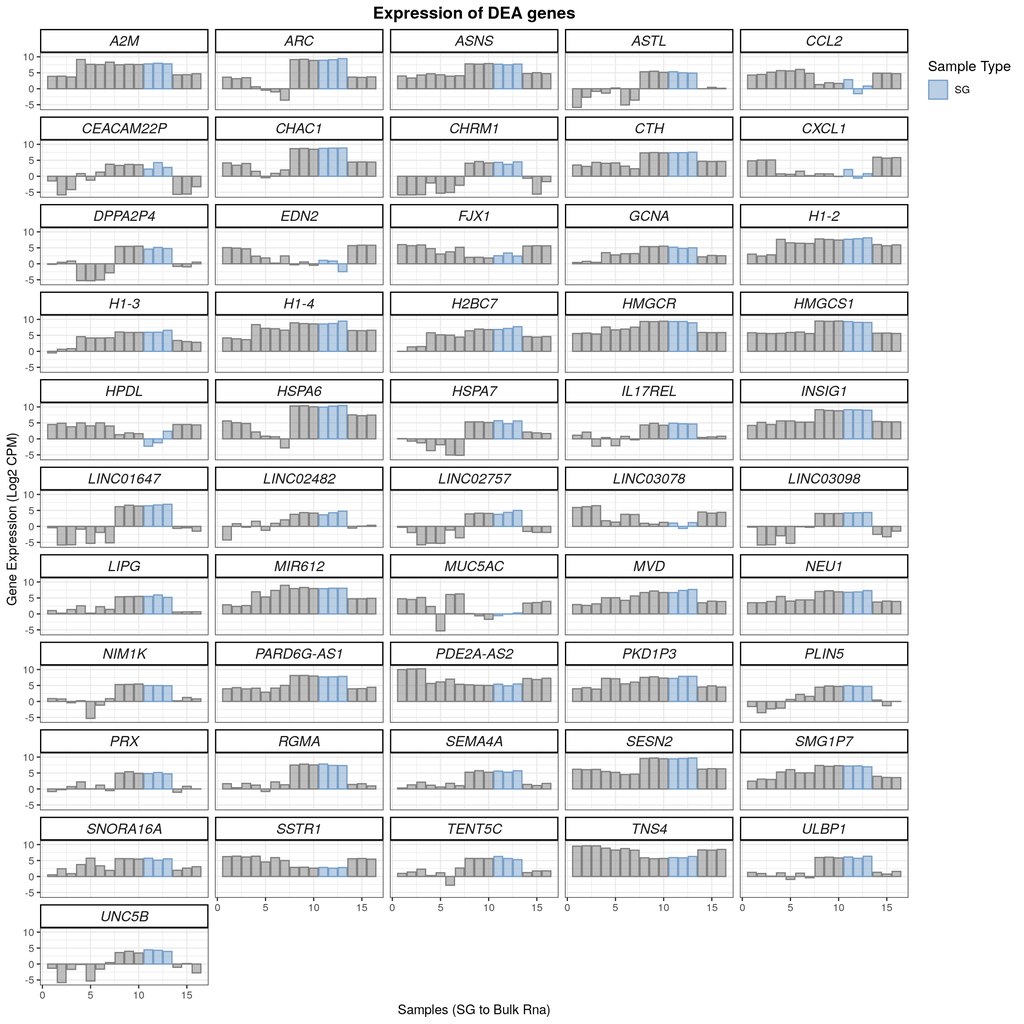

```r
finagenes <- rbind(upmarkers, downmarkers)


dfforexpression <- dfforpca
samplecodes <- data.frame(samples=row.names(dfforexpression), purity=c(1:16))
sampletype <- data.frame(samples=row.names(dfforexpression), sampletype=Sample_names)
dfforexpression <- t(dfforexpression)
genesforexp <- dfforexpression[row.names(dfforexpression)%in%row.names(finagenes),]
genesforexp <- reshape2::melt(genesforexp)
colnames(genesforexp) <- c("Gene", "samples", "expression")
genesforexp <- merge(genesforexp, samplecodes, by="samples")
genesforexp <- merge(genesforexp, sampletype, by="samples")
genesforexp <- genesforexp[,-1]
genesforexp[,2] <- as.numeric(genesforexp[,2])
genesforexp[,1] <- as.character(genesforexp[,1])
genesforexp <- genesforexp[order(genesforexp$Gene),]


winnyplot <- ggplot(genesforexp, aes(x=purity, y=expression, fill=sampletype, colour=sampletype)) + geom_bar(position="dodge", stat="identity", alpha=0.5) + facet_wrap(.~ Gene, ncol=5)
winnyplot <- winnyplot + scale_fill_manual(name = "Sample Type", values = custom_palette, breaks = unique(Sample_names)) + scale_colour_manual(name = "Sample Type", values = custom_palette, breaks = unique(Sample_names))
winnyplot <- winnyplot + theme_bw() + xlab("Samples (SG to Bulk Rna)") + ylab("Gene Expression (Log2 CPM)") + theme(
      strip.text.x = element_text(
        size = 12, face="italic"
        )) +
 theme(
   strip.background = element_rect(
     color="black", fill="#FFFFFF", size=1, linetype="solid"
     )
   ) + theme(
    #legend.position = c(.95, .40),
    legend.justification = c("right", "top"),
    legend.box.just = "right",
    ) + theme(legend.title = element_text(size = 12)) + ggtitle("Expression of DEA genes") + theme(plot.title = element_text(hjust = 0.5, size=14, face="bold"))
winnyplot
```

## GSEA Enrichment

Now that we have our genes of interest, it would also be interesting to see what are the **altered gene sets** between upregulated and downregulated transcripts from the above comparison. Therefore, lets perform a *Gene Set Enrichment Analysis*

```r
#for all genes
DEGenes <- DEGenes[order(DEGenes[,4]),]
gseatool <- DEGenes[,4]
gseatool <- as.data.frame(gseatool)
colnames(gseatool)[1] <- "t"
gseatool[,2] <- DEGenes$Gene
colnames(gseatool)[2] <- "Symbol"
gseatool <- gseatool[,c(2,1)]

vectorranks <- gseatool$t
names(vectorranks) <- gseatool$Symbol


#to load our pathways
hallmarks.gs <- msigdbr(species = "Homo sapiens", collection =  "H")

hallmarks.gsets <- hallmarks.gs %>% split(x = .$gene_symbol, f = .$gs_name)

for (set in names(hallmarks.gsets)){
  hallmarks.gsets[[set]] <- toupper(hallmarks.gsets[[set]])
}

hallmarks.res <- fgsea(pathways = hallmarks.gsets,
                       stats = vectorranks)
```

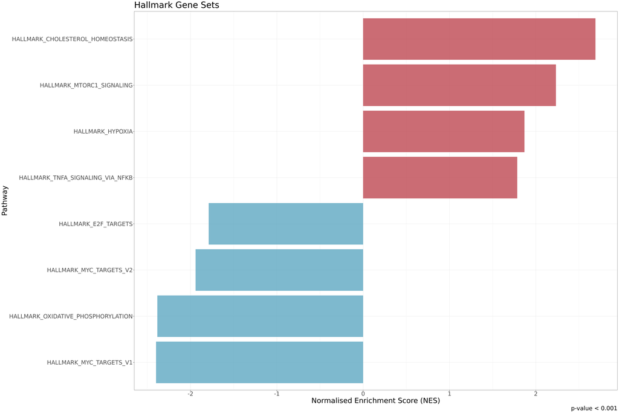

```r
hallmarks.res.tidy <- hallmarks.res %>%
  as_tibble() %>%
  arrange(desc(NES))

hallmarks.res.tidy %>%
  dplyr::select(-leadingEdge, -ES) %>%
  arrange(padj)

hallmark.sg.t <- hallmarks.res.tidy[,c(1,3,6)]
hallmark.sg.t <- as.data.frame(hallmark.sg.t)

#this small part is generic
thresh <- 0.001

#this one is no longer generic
data_to_plot <- hallmarks.res.tidy %>% filter(padj < thresh)

statvec <- c()
for (i in 1:nrow(data_to_plot)){
  if (data_to_plot[i,6] > 0){
    status <- "Upregulated"
  }
 else {
   status <- "Downregulated"
 }
statvec <- c(statvec, status)
}

data_to_plot$Status <- statvec

##-----HALMARK-----
gsea_plot_hall <- ggplot(data_to_plot, aes(reorder(pathway, NES), NES)) +
  geom_col(aes(fill= Status), alpha=0.75) + scale_fill_manual(values = c("#53A2BE","#BA3B46"), name = "Regulation Status", labels = c("Downregulated", "Upregulated"), breaks = c("Downregulated", "Upregulated")) +
  coord_flip() +
  labs(x="Pathway", y="Normalised Enrichment Score (NES)",
       title= "Hallmark Gene Sets",
       caption = paste0("p-value < ", thresh)) + theme(plot.title = element_text(hjust = 1)) +
  theme_bw() + theme(text=element_text(family = "Quicksand")) + theme(legend.position = "none")


gsea_plot_hall+
  theme(text=element_text(size=25,  family="Arial MS"))
```

### For Mito

```r
# --- Rank genes by t-statistic as usual ---
DEGenes <- DEGenes[order(DEGenes[,4]),]
gseatool <- DEGenes[,4]
gseatool <- as.data.frame(gseatool)
colnames(gseatool)[1] <- "t"
gseatool[,2] <- row.names(DEGenes)
colnames(gseatool)[2] <- "Symbol"
gseatool <- gseatool[,c(2,1)]
vectorranks <- gseatool$t
names(vectorranks) <- gseatool$Symbol

# --- Define MitoGenes as a custom gene set ---
MitoGenes <- fread("~/MitoGenes.txt")[[1]]
custom.gsets <- list(MitoGenes = toupper(MitoGenes))

# --- Run fgsea ---
mito.res <- fgsea(pathways = custom.gsets,
                  stats = vectorranks)
```

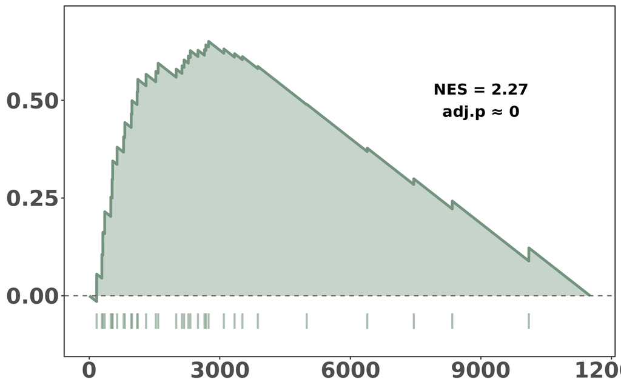

```r
mito.plot.base <- plotEnrichment(custom.gsets[["MitoGenes"]], vectorranks)
curve.data <- mito.plot.base$data

# --- key fix: match the curve's internal descending order ---
ord <- order(vectorranks, decreasing = TRUE)
ranked.names <- names(vectorranks)[ord]
gene.positions <- which(ranked.names %in% custom.gsets[["MitoGenes"]])

rug.top    <- min(curve.data$y) - 0.03
rug.bottom <- rug.top - 0.04

y.min <- rug.bottom - 0.03
y.max <- max(curve.data$y) + 0.05

(mito.plot <- ggplot(curve.data, aes(x = x, y = y)) +
  geom_area(fill = "#73937E", alpha = 0.4) +
  geom_line(color = "#73937E", linewidth = 1.2) +
  geom_hline(yintercept = 0, linetype = "dashed", color = "grey40") +
  geom_segment(data = data.frame(x = gene.positions),
               aes(x = x, xend = x, y = rug.top, yend = rug.bottom),
               color = "#73937E", alpha = 0.6, linewidth = 0.9,
               inherit.aes = FALSE) +
  annotate("text", x = 9000, y = 0.5,
           label = paste0("NES = ", round(mito.res$NES, 2),
                          "\nadj.p ≈ ", round(mito.res$padj, 4)),
           size = 5, family = "Arial MS", fontface = "bold") +
  coord_cartesian(ylim = c(y.min, y.max), clip = "off") +
  theme_bw() +
  theme(text = element_text(size = 25, family = "Arial MS"),
        plot.title = element_text(hjust = 0.5, face = "bold"),
        axis.title = element_blank(),
        axis.text = element_text(face = "bold"),
        panel.grid.minor = element_blank(),
        panel.grid.major = element_blank()))
```

```r
png("~/Projects/StressGranules/SGPAPER/Images/PNG/MitoGSEA_Raja.png", width=7, height=6, units="in", res=300)
mito.plot
dev.off()
```

### For Nuc

```r
# --- Rank genes by t-statistic as usual ---
DEGenes <- DEGenes[order(DEGenes[,4]),]
gseatool <- DEGenes[,4]
gseatool <- as.data.frame(gseatool)
colnames(gseatool)[1] <- "t"
gseatool[,2] <- row.names(DEGenes)
colnames(gseatool)[2] <- "Symbol"
gseatool <- gseatool[,c(2,1)]
vectorranks <- gseatool$t
names(vectorranks) <- gseatool$Symbol

# --- Define MitoGenes as a custom gene set ---
MitoGenes <- fread("~/rnalocate_mito_filt.csv")[[1]]
custom.gsets <- list(MitoGenes = toupper(MitoGenes))

# --- Run fgsea ---
mito.res <- fgsea(pathways = custom.gsets,
                  stats = vectorranks)
```

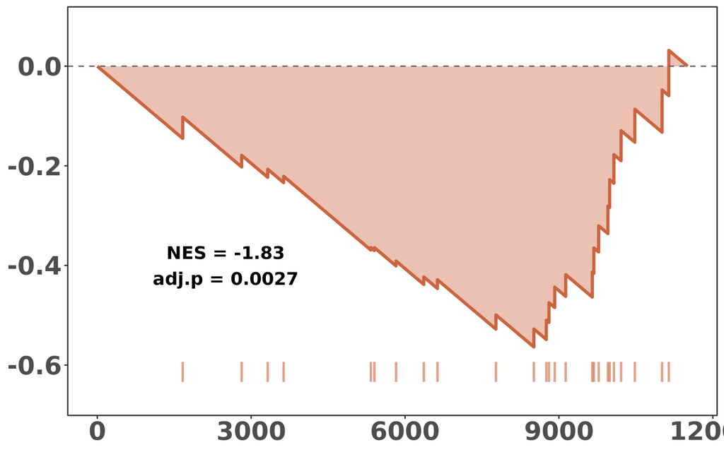

```r
mito.plot.base <- plotEnrichment(custom.gsets[["MitoGenes"]], vectorranks)
curve.data <- mito.plot.base$data

# --- key fix: match the curve's internal descending order ---
ord <- order(vectorranks, decreasing = TRUE)
ranked.names <- names(vectorranks)[ord]
gene.positions <- which(ranked.names %in% custom.gsets[["MitoGenes"]])

rug.top    <- min(curve.data$y) - 0.03
rug.bottom <- rug.top - 0.04

y.min <- rug.bottom - 0.03
y.max <- max(curve.data$y) + 0.05

(mito.plot <- ggplot(curve.data, aes(x = x, y = y)) +
  geom_area(fill = "#CB643F", alpha = 0.4) +
  geom_line(color = "#CB643F", linewidth = 1.2) +
  geom_hline(yintercept = 0, linetype = "dashed", color = "grey40") +
  geom_segment(data = data.frame(x = gene.positions),
               aes(x = x, xend = x, y = rug.top, yend = rug.bottom),
               color = "#CB643F", alpha = 0.6, linewidth = 0.9,
               inherit.aes = FALSE) +
  annotate("text", x = 2500, y = -0.4,
           label = paste0("NES = ", round(mito.res$NES, 2),
                          "\nadj.p = ", round(mito.res$padj, 4)),
           size = 5, family = "Arial MS", fontface = "bold") +
  coord_cartesian(ylim = c(y.min, y.max), clip = "off") +
  theme_bw() +
  theme(text = element_text(size = 25, family = "Arial MS"),
        plot.title = element_text(hjust = 0.5, face = "bold"),
        axis.title = element_blank(),
        axis.text = element_text(face = "bold"),
        panel.grid.minor = element_blank(),
        panel.grid.major = element_blank()))
```

```r
png("~/Projects/StressGranules/SGPAPER/Images/PNG/NucGSEA_Raja.png", width=7, height=6, units="in", res=300)
mito.plot
dev.off()
```

[^1]: Disease Transcriptomics Group, Gulbenkian Institute of Molecular Medicine